# APIM - Control - Final Models

Pascal Küng, MSc, Patrick Höhener, MSc, James M. Allen, PhD, Robert Tobias, PhD, Urte Scholz, PhD

2025-02-28

```r
knitr::opts_chunk$set(echo = TRUE)

rm(list = ls())

#cmdstanr::set_cmdstan_path(path = "C:/Users/kueng/.cmdstan/cmdstan-2.35.0")
#cmdstanr::set_cmdstan_path(path = "C:/Users/pascku/.cmdstan/cmdstan-2.36.0")

library(tidyverse)
library(R.utils)
library(wbCorr)
library(readxl)
library(kableExtra)
library(brms)
library(bayesplot)
library(see)
library(beepr)
library(DHARMa)
library(digest)



source(file.path('Functions', 'ReportModels.R'))
source(file.path('Functions', 'PrettyTables.R'))
source(file.path('Functions', 'ReportMeasures.R'))
source(file.path('Functions', 'PrepareData.R'))
```

```r
system("shutdown /a")
```

```
## [1] 1116
```

```r
# Set options for analysis
use_mi = FALSE
shutdown = FALSE
report_ordinal = FALSE
do_priorsense = FALSE
get_bayesfactor = FALSE
check_models = FALSE #

if (get_bayesfactor) {
  stats_to_report <- c('CI', 'SE', 'pd', 'ROPE', 'BF', 'Rhat', 'ESS')
} else {
  stats_to_report <- c('CI', 'SE', 'pd', 'ROPE', 'Rhat', 'ESS')
}

options(
  dplyr.print_max = 100,
  brms.backend = 'cmdstan',
  brms.file_refit = ifelse(use_mi, 'never', 'on_change'),
  brms.file_refit = 'on_change',
  #brms.file_refit = 'always',
  error = function() {
    beepr::beep(sound = 5)
    if (shutdown) {
      system("shutdown /s /t 180")
      quit(save = "no", status = 1)
    }
  }
  , es.use_symbols = TRUE
)


####################### Model parameters #######################

iterations = 2000 # 12'000 per chain to achieve 40'000
warmup = 1000 # 2000

# NO AR!!!
#corstr = 'ar'
#corstr = 'cosy_couple'
#corstr = 'cosy_couple:user'


################################################################

suffix = paste0('_as_preregistered_new_', as.character(iterations))
```

```r
df <- openxlsx::read.xlsx(file.path('long.xlsx'))
df_original <- df

df_double <- prepare_data(df, recode_pushing = TRUE, use_mi = use_mi)[[1]]
```

Constructing scales Re-coding pusing reshaping data (4field) centering data within and between

```r
summary(df_double$pushing)
```

Min. 1st Qu. Median Mean 3rd Qu. Max. NA’s 0.0000 0.0000 0.0000 0.1649 0.0000 5.0000 275

# Prepare for APIM

```r
df_double$is_A <- ifelse(df_double$pa_obj_self_cb >= df_double$pa_obj_partner_cb, 0, 1)
df_double$is_B <- ifelse(df_double$pa_obj_self_cb < df_double$pa_obj_partner_cb, 0, 1)
```

# Modelling

## Self-Reported MVPA

### Persuasion

```r
formula <- bf(
  pa_sub ~ 0 +
    is_A + is_B + # Intercepts
    is_A:persuasion_self_cw + is_B:persuasion_self_cw +
    is_A:persuasion_partner_cw + is_B:persuasion_partner_cw +

    is_A:persuasion_self_cb + is_B:persuasion_self_cb +
    is_A:persuasion_partner_cb + is_B:persuasion_partner_cb +

    #is_A:plan_self + is_B:plan_self +
    #is_A:plan_partner + is_B:plan_partner +
    is_A:day + is_B:day +

    # Random effects
    (0 +
    is_A + is_B + # Intercepts
    is_A:persuasion_self_cw + is_B:persuasion_self_cw +
    is_A:persuasion_partner_cw + is_B:persuasion_partner_cw |dd| coupleID),

  hu = ~ 0 +
    is_A + is_B + # Intercepts
    is_A:persuasion_self_cw + is_B:persuasion_self_cw +
    is_A:persuasion_partner_cw + is_B:persuasion_partner_cw +

    is_A:persuasion_self_cb + is_B:persuasion_self_cb +
    is_A:persuasion_partner_cb + is_B:persuasion_partner_cb +

    #is_A:plan_self + is_B:plan_self +
    #is_A:plan_partner + is_B:plan_partner +
    is_A:day + is_B:day +

    # Random effects
    (0 +
    is_A + is_B + # Intercepts
    is_A:persuasion_self_cw + is_B:persuasion_self_cw +
    is_A:persuasion_partner_cw + is_B:persuasion_partner_cw |dd| coupleID)

  , decomp = 'QR'
  #, autocor = autocor_str
)

prior1 <- c(
  brms::set_prior("normal(0, 2.5)", class = "b")
  , brms::set_prior("normal(0, 2)", class = "b", dpar = "hu")

  , brms::set_prior("normal(0, 50)", class = "b", coef = 'is_A')
  , brms::set_prior("normal(0, 50)", class = "b", coef = 'is_B')

  , brms::set_prior("normal(0.5, 2.5)", class = "b", coef = 'is_A', dpar = 'hu')
  , brms::set_prior("normal(0.5, 2.5)", class = "b", coef = 'is_B', dpar = 'hu')

  , brms::set_prior("normal(0, 2)", class = "sd", group = "coupleID", lb = 0)
  , brms::set_prior("student_t(3, 0, 2.5)", class = "sigma", lb = 0)
)

#brms::validate_prior(
#  prior1,
#  formula = formula,
#  data = df_double,
#  family = hurdle_lognormal()
#)

#df_minimal <- df_double[, c("AorB", all.vars(as.formula(formula)))]

pa_sub_persuasion <- my_brm(
  mi = use_mi,
  imputed_data = implist,

  formula = formula,
  prior = prior1,
  data = df_double,
  family = brms::hurdle_lognormal(),
  #family = brms::hurdle_negbinomial(),
  #family = brms::hurdle_poisson(),
  #control = list(adapt_delta = 0.95, max_treedepth = 15),
  iter = iterations,
  warmup = warmup,
  chains = 4,
  cores = 4,
  seed = 42,
  file = file.path("models_cache_brms", paste0("pa_sub_hu_lognormal_persuasion", suffix))
  #, file_refit = 'always'
)
if (check_models) {
  check_brms(pa_sub_persuasion, log_pp_check = TRUE)
  DHARMa.check_brms.all(pa_sub_persuasion, integer = TRUE, outliers_type = 'bootstrap')
}
```

```r
# rope range for continuous part of the model
rope_factor <- sd(log(pa_sub_persuasion$data$pa_sub[pa_sub_persuasion$data$pa_sub > 0]))
rope_range_continuous = c(-0.1 * rope_factor, 0.1 * rope_factor)

summary_pa_sub <- summarize_brms(
  pa_sub_persuasion,
  stats_to_report = stats_to_report,
  rope_range = rope_range_continuous,
  hu_rope_range = c(-0.18, 0.18),
  #model_rows_fixed = model_rows_fixed,
  #model_rows_random = model_rows_random,
  #model_rownames_fixed = model_rownames_fixed,
  #model_rownames_random = model_rownames_random,
  exponentiate = T)
```

```
## Model has no intercept. VIFs may not be sensible.
## Model has no intercept. VIFs may not be sensible.
```

```r
# Print the updated dataframe
summary_pa_sub %>%
  print_df(
    #rows_to_pack = rows_to_pack
    )
```

|  | exp(Est.)_hu | SE_hu | 95% CI_hu | pd_hu | ROPE_hu | inside ROPE_hu | Rhat_hu | Bulk_ESS_hu | Tail_ESS_hu | exp(Est.)_nonzero | SE_nonzero | 95% CI_nonzero | pd_nonzero | ROPE_nonzero | inside ROPE_nonzero | Rhat_nonzero | Bulk_ESS_nonzero | Tail_ESS_nonzero |
| --- | --- | --- | --- | --- | --- | --- | --- | --- | --- | --- | --- | --- | --- | --- | --- | --- | --- | --- |
| is_A | 0.74 | 0.14 | [ 0.51, 1.08] | 0.939 | [0.84, 1.20] | 0.270 | 1.002 | 2269 | 2450 | 46.64*** | 3.64 | [39.95, 53.88] | 1.000 | [0.92, 1.08] | 0.000 | 1.000 | 1427 | 2428 |
| is_A:day | 0.97 | 0.18 | [ 0.67, 1.41] | 0.575 | [0.84, 1.20] | 0.650 | 1.001 | 5389 | 2918 | 1.09 | 0.09 | [ 0.92, 1.29] | 0.851 | [0.92, 1.08] | 0.434 | 1.002 | 4676 | 2918 |
| is_A:persuasion_partner_cb | 0.76 | 0.30 | [ 0.32, 1.62] | 0.765 | [0.84, 1.20] | 0.286 | 1.001 | 1551 | 2445 | 1.03 | 0.17 | [ 0.75, 1.42] | 0.568 | [0.92, 1.08] | 0.365 | 1.002 | 1518 | 2131 |
| is_A:persuasion_partner_cw | 1.58*** | 0.16 | [ 1.29, 1.97] | 1.000 | [0.84, 1.20] | 0.004 | 1.000 | 2783 | 3038 | 1.02 | 0.03 | [ 0.96, 1.08] | 0.716 | [0.92, 1.08] | 0.981 | 1.001 | 2593 | 2466 |
| is_A:persuasion_self_cb | 0.81 | 0.38 | [ 0.33, 1.99] | 0.677 | [0.84, 1.20] | 0.274 | 1.000 | 1243 | 2299 | 1.21 | 0.21 | [ 0.84, 1.73] | 0.866 | [0.92, 1.08] | 0.190 | 1.002 | 1506 | 2250 |
| is_A:persuasion_self_cw | 1.67*** | 0.16 | [ 1.41, 2.09] | 1.000 | [0.84, 1.20] | 0.000 | 1.002 | 2279 | 1744 | 1.01 | 0.04 | [ 0.94, 1.09] | 0.650 | [0.92, 1.08] | 0.935 | 1.005 | 1848 | 2443 |
| is_B | 0.92 | 0.18 | [ 0.63, 1.37] | 0.657 | [0.84, 1.20] | 0.589 | 1.002 | 2113 | 2747 | 49.88*** | 3.87 | [42.42, 57.98] | 1.000 | [0.92, 1.08] | 0.000 | 1.004 | 1498 | 2350 |
| is_B:day | 0.87 | 0.16 | [ 0.61, 1.27] | 0.776 | [0.84, 1.20] | 0.542 | 1.002 | 5012 | 2585 | 0.88 | 0.07 | [ 0.75, 1.03] | 0.946 | [0.92, 1.08] | 0.246 | 1.000 | 5060 | 2971 |
| is_B:persuasion_partner_cb | 1.01 | 0.50 | [ 0.38, 2.59] | 0.507 | [0.84, 1.20] | 0.276 | 1.001 | 1212 | 1923 | 1.03 | 0.20 | [ 0.71, 1.48] | 0.562 | [0.92, 1.08] | 0.319 | 1.003 | 1293 | 1942 |
| is_B:persuasion_partner_cw | 1.48*** | 0.14 | [ 1.24, 1.85] | 1.000 | [0.84, 1.20] | 0.011 | 1.001 | 3118 | 1930 | 1.03 | 0.03 | [ 0.97, 1.10] | 0.850 | [0.92, 1.08] | 0.929 | 1.001 | 2987 | 2511 |
| is_B:persuasion_self_cb | 0.70 | 0.30 | [ 0.30, 1.58] | 0.797 | [0.84, 1.20] | 0.234 | 1.001 | 1614 | 2463 | 1.13 | 0.18 | [ 0.81, 1.56] | 0.769 | [0.92, 1.08] | 0.271 | 1.002 | 1431 | 2204 |
| is_B:persuasion_self_cw | 1.68*** | 0.17 | [ 1.39, 2.12] | 1.000 | [0.84, 1.20] | 0.001 | 1.000 | 2613 | 2076 | 1.03 | 0.03 | [ 0.98, 1.10] | 0.876 | [0.92, 1.08] | 0.932 | 1.001 | 2680 | 3144 |
| sd(is_A) | 0.94 | 0.13 | [0.73, 1.23] | NA | NA | NA | 1.002 | 1960 | 2814 | 0.33 | 0.05 | [0.25, 0.45] | NA | NA | NA | 1.001 | 1331 | 2454 |
| sd(is_A:persuasion_partner_cw) | 0.42 | 0.11 | [0.21, 0.70] | NA | NA | NA | 1.000 | 1999 | 2257 | 0.06 | 0.03 | [0.01, 0.13] | NA | NA | NA | 1.006 | 1037 | 757 |
| sd(is_A:persuasion_self_cw) | 0.29 | 0.13 | [0.05, 0.59] | NA | NA | NA | 1.003 | 1124 | 1201 | 0.17 | 0.03 | [0.11, 0.23] | NA | NA | NA | 1.004 | 2044 | 2529 |
| sd(is_B) | 1.01 | 0.13 | [0.79, 1.32] | NA | NA | NA | 1.001 | 2288 | 2551 | 0.39 | 0.05 | [0.30, 0.50] | NA | NA | NA | 1.001 | 1665 | 2636 |
| sd(is_B:persuasion_partner_cw) | 0.33 | 0.14 | [0.05, 0.63] | NA | NA | NA | 1.003 | 1118 | 958 | 0.10 | 0.03 | [0.05, 0.17] | NA | NA | NA | 1.003 | 2312 | 2581 |
| sd(is_B:persuasion_self_cw) | 0.38 | 0.11 | [0.19, 0.62] | NA | NA | NA | 1.000 | 2229 | 2918 | 0.09 | 0.03 | [0.05, 0.16] | NA | NA | NA | 1.001 | 2289 | 2531 |
| sigma | NA | NA | NA | NA | NA | NA | NA | NA | NA | 0.67 | 0.01 | [0.65, 0.70] | NA | NA | NA | 1.001 | 5885 | 2983 |

Hurdle part of the model on the left, non-zero part towards the right side of the table

### Pressure

```r
formula <- bf(
  pa_sub ~ 0 +
    is_A + is_B + # Intercepts
    is_A:pressure_self_cw + is_B:pressure_self_cw +
    is_A:pressure_partner_cw + is_B:pressure_partner_cw +

    is_A:pressure_self_cb + is_B:pressure_self_cb +
    is_A:pressure_partner_cb + is_B:pressure_partner_cb +

    #is_A:plan_self + is_B:plan_self +
    #is_A:plan_partner + is_B:plan_partner +
    is_A:day + is_B:day +

    # Random effects
    (0 +
    is_A + is_B + # Intercepts
    is_A:pressure_self_cw + is_B:pressure_self_cw +
    is_A:pressure_partner_cw + is_B:pressure_partner_cw |dd| coupleID),

  hu = ~ 0 +
    is_A + is_B + # Intercepts
    is_A:pressure_self_cw + is_B:pressure_self_cw +
    is_A:pressure_partner_cw + is_B:pressure_partner_cw +

    is_A:pressure_self_cb + is_B:pressure_self_cb +
    is_A:pressure_partner_cb + is_B:pressure_partner_cb +

    #is_A:plan_self + is_B:plan_self +
    #is_A:plan_partner + is_B:plan_partner +
    is_A:day + is_B:day +

    # Random effects
    (0 +
    is_A + is_B + # Intercepts
    is_A:pressure_self_cw + is_B:pressure_self_cw +
    is_A:pressure_partner_cw + is_B:pressure_partner_cw |dd| coupleID)

  , decomp = 'QR'
  #, autocor = autocor_str
)

prior1 <- c(
  brms::set_prior("normal(0, 2.5)", class = "b")
  , brms::set_prior("normal(0, 2)", class = "b", dpar = "hu")

  , brms::set_prior("normal(0, 50)", class = "b", coef = 'is_A')
  , brms::set_prior("normal(0, 50)", class = "b", coef = 'is_B')

  , brms::set_prior("normal(0.5, 2.5)", class = "b", coef = 'is_A', dpar = 'hu')
  , brms::set_prior("normal(0.5, 2.5)", class = "b", coef = 'is_B', dpar = 'hu')

  , brms::set_prior("normal(0, 2)", class = "sd", group = "coupleID", lb = 0)
  , brms::set_prior("student_t(3, 0, 2.5)", class = "sigma", lb = 0)
)

#brms::validate_prior(
#  prior1,
#  formula = formula,
#  data = df_double,
#  family = hurdle_lognormal()
#)

#df_minimal <- df_double[, c("AorB", all.vars(as.formula(formula)))]

pa_sub_pressure <- my_brm(
  mi = use_mi,
  imputed_data = implist,

  formula = formula,
  prior = prior1,
  data = df_double,
  family = brms::hurdle_lognormal(),
  #family = brms::hurdle_negbinomial(),
  #family = brms::hurdle_poisson(),
  #control = list(adapt_delta = 0.95, max_treedepth = 15),
  iter = iterations,
  warmup = warmup,
  chains = 4,
  cores = 4,
  seed = 42,
  file = file.path("models_cache_brms", paste0("pa_sub_hu_lognormal_pressure", suffix))
  #, file_refit = 'always'
)
if (check_models) {
  check_brms(pa_sub_pressure, log_pp_check = TRUE)
  DHARMa.check_brms.all(pa_sub_pressure, integer = TRUE, outliers_type = 'bootstrap')
}
```

```r
# rope range for continuous part of the model
rope_factor <- sd(log(pa_sub_pressure$data$pa_sub[pa_sub_pressure$data$pa_sub > 0]))
rope_range_continuous = c(-0.1 * rope_factor, 0.1 * rope_factor)

summary_pa_sub <- summarize_brms(
  pa_sub_pressure,
  stats_to_report = stats_to_report,
  rope_range = rope_range_continuous,
  hu_rope_range = c(-0.18, 0.18),
  #model_rows_fixed = model_rows_fixed,
  #model_rows_random = model_rows_random,
  #model_rownames_fixed = model_rownames_fixed,
  #model_rownames_random = model_rownames_random,
  exponentiate = T)
```

```
## Model has no intercept. VIFs may not be sensible.
## Model has no intercept. VIFs may not be sensible.
```

```r
# Print the updated dataframe
summary_pa_sub %>%
  print_df(
    #rows_to_pack = rows_to_pack
    )
```

|  | exp(Est.)_hu | SE_hu | 95% CI_hu | pd_hu | ROPE_hu | inside ROPE_hu | Rhat_hu | Bulk_ESS_hu | Tail_ESS_hu | exp(Est.)_nonzero | SE_nonzero | 95% CI_nonzero | pd_nonzero | ROPE_nonzero | inside ROPE_nonzero | Rhat_nonzero | Bulk_ESS_nonzero | Tail_ESS_nonzero |
| --- | --- | --- | --- | --- | --- | --- | --- | --- | --- | --- | --- | --- | --- | --- | --- | --- | --- | --- |
| is_A | 0.86 | 0.16 | [ 0.62, 1.22] | 0.778 | [0.84, 1.20] | 0.543 | 1.002 | 1619 | 2259 | 48.30*** | 3.53 | [41.60, 55.61] | 1.000 | [0.92, 1.08] | 0.000 | 1.001 | 1078 | 1836 |
| is_A:day | 0.68* | 0.11 | [ 0.49, 0.94] | 0.992 | [0.84, 1.20] | 0.102 | 1.000 | 3627 | 2877 | 1.09 | 0.09 | [ 0.93, 1.27] | 0.835 | [0.92, 1.08] | 0.455 | 1.000 | 5148 | 3217 |
| is_A:pressure_partner_cb | 0.63 | 0.38 | [ 0.19, 2.19] | 0.768 | [0.84, 1.20] | 0.170 | 1.002 | 1387 | 2231 | 0.94 | 0.27 | [ 0.54, 1.65] | 0.581 | [0.92, 1.08] | 0.210 | 1.004 | 1193 | 2193 |
| is_A:pressure_partner_cw | 2.43*** | 0.57 | [ 1.58, 4.20] | 1.000 | [0.84, 1.20] | 0.000 | 1.001 | 3014 | 2270 | 0.94 | 0.05 | [ 0.84, 1.05] | 0.882 | [0.92, 1.08] | 0.574 | 1.000 | 3919 | 2837 |
| is_A:pressure_self_cb | 0.56 | 0.43 | [ 0.13, 2.53] | 0.774 | [0.84, 1.20] | 0.143 | 1.001 | 1507 | 2224 | 1.56 | 0.52 | [ 0.79, 3.18] | 0.907 | [0.92, 1.08] | 0.071 | 1.005 | 1500 | 2130 |
| is_A:pressure_self_cw | 1.82* | 0.59 | [ 1.03, 4.33] | 0.978 | [0.84, 1.20] | 0.061 | 1.001 | 2051 | 1761 | 0.85* | 0.06 | [ 0.72, 0.99] | 0.980 | [0.92, 1.08] | 0.135 | 1.001 | 2715 | 2077 |
| is_B | 1.14 | 0.22 | [ 0.80, 1.65] | 0.769 | [0.84, 1.20] | 0.551 | 1.002 | 1294 | 1946 | 52.19*** | 4.31 | [44.52, 61.49] | 1.000 | [0.92, 1.08] | 0.000 | 1.003 | 875 | 1955 |
| is_B:day | 0.56*** | 0.10 | [ 0.39, 0.79] | 1.000 | [0.84, 1.20] | 0.011 | 1.000 | 4000 | 3081 | 0.83* | 0.07 | [ 0.72, 0.97] | 0.990 | [0.92, 1.08] | 0.090 | 1.000 | 4854 | 3016 |
| is_B:pressure_partner_cb | 1.15 | 0.87 | [ 0.26, 5.29] | 0.568 | [0.84, 1.20] | 0.186 | 1.001 | 1340 | 1906 | 1.09 | 0.44 | [ 0.48, 2.50] | 0.586 | [0.92, 1.08] | 0.156 | 1.003 | 1237 | 1738 |
| is_B:pressure_partner_cw | 3.33* | 2.03 | [ 1.23, 16.18] | 0.989 | [0.84, 1.20] | 0.017 | 1.001 | 1929 | 2039 | 0.99 | 0.07 | [ 0.82, 1.13] | 0.567 | [0.92, 1.08] | 0.718 | 1.000 | 2374 | 2131 |
| is_B:pressure_self_cb | 0.48 | 0.29 | [ 0.13, 1.54] | 0.893 | [0.84, 1.20] | 0.116 | 1.001 | 1311 | 2034 | 1.08 | 0.34 | [ 0.55, 2.03] | 0.591 | [0.92, 1.08] | 0.189 | 1.001 | 1278 | 2026 |
| is_B:pressure_self_cw | 1.29 | 0.35 | [ 0.65, 2.65] | 0.828 | [0.84, 1.20] | 0.316 | 1.001 | 2208 | 1848 | 0.94 | 0.06 | [ 0.82, 1.08] | 0.834 | [0.92, 1.08] | 0.548 | 1.002 | 2727 | 2429 |
| sd(is_A) | 0.88 | 0.12 | [0.69, 1.15] | NA | NA | NA | 1.001 | 1982 | 2636 | 0.32 | 0.05 | [0.24, 0.43] | NA | NA | NA | 1.004 | 1243 | 2039 |
| sd(is_A:pressure_partner_cw) | 0.30 | 0.28 | [0.01, 1.22] | NA | NA | NA | 1.001 | 1672 | 1800 | 0.06 | 0.05 | [0.00, 0.21] | NA | NA | NA | 1.000 | 2120 | 2016 |
| sd(is_A:pressure_self_cw) | 0.70 | 0.51 | [0.06, 2.24] | NA | NA | NA | 1.004 | 1258 | 1332 | 0.10 | 0.08 | [0.00, 0.37] | NA | NA | NA | 1.001 | 1512 | 1566 |
| sd(is_B) | 0.91 | 0.12 | [0.70, 1.19] | NA | NA | NA | 1.002 | 1828 | 2298 | 0.40 | 0.06 | [0.31, 0.52] | NA | NA | NA | 1.005 | 1150 | 2250 |
| sd(is_B:pressure_partner_cw) | 1.67 | 0.87 | [0.36, 3.91] | NA | NA | NA | 1.002 | 1273 | 960 | 0.09 | 0.08 | [0.00, 0.37] | NA | NA | NA | 1.001 | 1324 | 1668 |
| sd(is_B:pressure_self_cw) | 0.75 | 0.49 | [0.06, 2.09] | NA | NA | NA | 1.005 | 1011 | 980 | 0.09 | 0.07 | [0.01, 0.28] | NA | NA | NA | 1.001 | 1633 | 1710 |
| sigma | NA | NA | NA | NA | NA | NA | NA | NA | NA | 0.69 | 0.01 | [0.67, 0.72] | NA | NA | NA | 1.000 | 4519 | 3405 |

Hurdle part of the model on the left, non-zero part towards the right side of the table

### Pushing

```r
formula <- bf(
  pa_sub ~ 0 +
    is_A + is_B + # Intercepts
    is_A:pushing_self_cw + is_B:pushing_self_cw +
    is_A:pushing_partner_cw + is_B:pushing_partner_cw +

    is_A:pushing_self_cb + is_B:pushing_self_cb +
    is_A:pushing_partner_cb + is_B:pushing_partner_cb +

    #is_A:plan_self + is_B:plan_self +
    #is_A:plan_partner + is_B:plan_partner +
    barriers_self_cw + barriers_self_cb +
    is_A:day + is_B:day +

    # Random effects
    (0 +
    is_A + is_B + # Intercepts
    is_A:pushing_self_cw + is_B:pushing_self_cw +
    is_A:pushing_partner_cw + is_B:pushing_partner_cw |dd| coupleID),

  hu = ~ 0 +
    is_A + is_B + # Intercepts
    is_A:pushing_self_cw + is_B:pushing_self_cw +
    is_A:pushing_partner_cw + is_B:pushing_partner_cw +

    is_A:pushing_self_cb + is_B:pushing_self_cb +
    is_A:pushing_partner_cb + is_B:pushing_partner_cb +

    #is_A:plan_self + is_B:plan_self +
    #is_A:plan_partner + is_B:plan_partner +
    is_A:day + is_B:day +

    # Random effects
    (0 +
    is_A + is_B + # Intercepts
    is_A:pushing_self_cw + is_B:pushing_self_cw +
    is_A:pushing_partner_cw + is_B:pushing_partner_cw |dd| coupleID)

  , decomp = 'QR'
  #, autocor = autocor_str
)

prior1 <- c(
  brms::set_prior("normal(0, 2.5)", class = "b")
  , brms::set_prior("normal(0, 2)", class = "b", dpar = "hu")

  , brms::set_prior("normal(0, 50)", class = "b", coef = 'is_A')
  , brms::set_prior("normal(0, 50)", class = "b", coef = 'is_B')

  , brms::set_prior("normal(0.5, 2.5)", class = "b", coef = 'is_A', dpar = 'hu')
  , brms::set_prior("normal(0.5, 2.5)", class = "b", coef = 'is_B', dpar = 'hu')

  , brms::set_prior("normal(0, 2)", class = "sd", group = "coupleID", lb = 0)
  , brms::set_prior("student_t(3, 0, 2.5)", class = "sigma", lb = 0)
)

#brms::validate_prior(
#  prior1,
#  formula = formula,
#  data = df_double,
#  family = hurdle_lognormal()
#)

#df_minimal <- df_double[, c("AorB", all.vars(as.formula(formula)))]

pa_sub_pushing <- my_brm(
  mi = use_mi,
  imputed_data = implist,

  formula = formula,
  prior = prior1,
  data = df_double,
  family = brms::hurdle_lognormal(),
  #family = brms::hurdle_negbinomial(),
  #family = brms::hurdle_poisson(),
  #control = list(adapt_delta = 0.95, max_treedepth = 15),
  iter = iterations,
  warmup = warmup,
  chains = 4,
  cores = 4,
  seed = 42,
  file = file.path("models_cache_brms", paste0("pa_sub_hu_lognormal_pushing", suffix))
  #, file_refit = 'always'
)
if (check_models) {
  check_brms(pa_sub_pushing, log_pp_check = TRUE)
  DHARMa.check_brms.all(pa_sub_pushing, integer = TRUE, outliers_type = 'bootstrap')
}
```

```r
# rope range for continuous part of the model
rope_factor <- sd(log(pa_sub_pushing$data$pa_sub[pa_sub_pushing$data$pa_sub > 0]))
rope_range_continuous = c(-0.1 * rope_factor, 0.1 * rope_factor)

summary_pa_sub <- summarize_brms(
  pa_sub_pushing,
  stats_to_report = stats_to_report,
  rope_range = rope_range_continuous,
  hu_rope_range = c(-0.18, 0.18),
  #model_rows_fixed = model_rows_fixed,
  #model_rows_random = model_rows_random,
  #model_rownames_fixed = model_rownames_fixed,
  #model_rownames_random = model_rownames_random,
  exponentiate = T)
```

```
## Model has no intercept. VIFs may not be sensible.
## Model has no intercept. VIFs may not be sensible.
```

```r
# Print the updated dataframe
summary_pa_sub %>%
  print_df(
    #rows_to_pack = rows_to_pack
    )
```

|  | exp(Est.)_hu | SE_hu | 95% CI_hu | pd_hu | ROPE_hu | inside ROPE_hu | Rhat_hu | Bulk_ESS_hu | Tail_ESS_hu | exp(Est.)_nonzero | SE_nonzero | 95% CI_nonzero | pd_nonzero | ROPE_nonzero | inside ROPE_nonzero | Rhat_nonzero | Bulk_ESS_nonzero | Tail_ESS_nonzero |
| --- | --- | --- | --- | --- | --- | --- | --- | --- | --- | --- | --- | --- | --- | --- | --- | --- | --- | --- |
| barriers_self_cb | NA | NA | NA | NA | NA | NA | NA | NA | NA | 1.09 | 0.07 | [ 0.97, 1.23] | 0.930 | [0.93, 1.08] | 0.412 | 1.002 | 946 | 1535 |
| barriers_self_cw | NA | NA | NA | NA | NA | NA | NA | NA | NA | 1.04** | 0.02 | [ 1.02, 1.08] | 0.999 | [0.93, 1.08] | 0.988 | 1.001 | 5867 | 3009 |
| is_A | 2.62** | 0.70 | [ 1.56, 4.49] | 0.999 | [0.84, 1.20] | 0.002 | 1.001 | 2288 | 2493 | 52.83*** | 4.31 | [45.03, 62.04] | 1.000 | [0.93, 1.08] | 0.000 | 1.003 | 1590 | 2238 |
| is_A:day | 0.81 | 0.24 | [ 0.44, 1.49] | 0.758 | [0.84, 1.20] | 0.362 | 1.000 | 4630 | 2913 | 1.07 | 0.10 | [ 0.89, 1.28] | 0.755 | [0.93, 1.08] | 0.484 | 1.003 | 6155 | 3188 |
| is_A:pushing_partner_cb | 0.94 | 0.87 | [ 0.13, 6.26] | 0.530 | [0.84, 1.20] | 0.165 | 1.000 | 2220 | 2436 | 1.03 | 0.36 | [ 0.51, 2.09] | 0.539 | [0.93, 1.08] | 0.169 | 1.004 | 1368 | 1972 |
| is_A:pushing_partner_cw | 1.95** | 0.46 | [ 1.31, 3.48] | 0.999 | [0.84, 1.20] | 0.010 | 1.001 | 3124 | 2706 | 0.97 | 0.03 | [ 0.90, 1.04] | 0.800 | [0.93, 1.08] | 0.913 | 1.001 | 4972 | 2649 |
| is_A:pushing_self_cb | 0.41 | 0.37 | [ 0.07, 2.22] | 0.850 | [0.84, 1.20] | 0.097 | 1.002 | 2427 | 2900 | 1.34 | 0.41 | [ 0.72, 2.52] | 0.836 | [0.93, 1.08] | 0.120 | 1.001 | 1927 | 2429 |
| is_A:pushing_self_cw | 1.91 | 0.78 | [ 0.93, 5.20] | 0.967 | [0.84, 1.20] | 0.080 | 1.002 | 2385 | 2578 | 1.02 | 0.06 | [ 0.91, 1.15] | 0.648 | [0.93, 1.08] | 0.800 | 1.001 | 2201 | 2564 |
| is_B | 4.02*** | 1.20 | [ 2.23, 7.54] | 1.000 | [0.84, 1.20] | 0.000 | 1.000 | 2269 | 2179 | 53.70*** | 4.59 | [45.03, 63.04] | 1.000 | [0.93, 1.08] | 0.000 | 1.003 | 1697 | 2469 |
| is_B:day | 0.64 | 0.20 | [ 0.36, 1.19] | 0.925 | [0.84, 1.20] | 0.180 | 1.000 | 4891 | 2943 | 0.92 | 0.08 | [ 0.78, 1.11] | 0.805 | [0.93, 1.08] | 0.444 | 1.000 | 6274 | 3002 |
| is_B:pushing_partner_cb | 0.83 | 0.81 | [ 0.11, 5.80] | 0.570 | [0.84, 1.20] | 0.139 | 1.001 | 2495 | 2944 | 1.07 | 0.33 | [ 0.57, 2.06] | 0.583 | [0.93, 1.08] | 0.191 | 1.000 | 1779 | 2389 |
| is_B:pushing_partner_cw | 2.29* | 1.10 | [ 1.05, 8.09] | 0.981 | [0.84, 1.20] | 0.040 | 1.002 | 2329 | 2035 | 1.03 | 0.06 | [ 0.93, 1.16] | 0.715 | [0.93, 1.08] | 0.769 | 1.000 | 2642 | 3014 |
| is_B:pushing_self_cb | 0.40 | 0.41 | [ 0.05, 3.24] | 0.811 | [0.84, 1.20] | 0.095 | 1.001 | 2854 | 2896 | 1.48 | 0.54 | [ 0.72, 3.11] | 0.859 | [0.93, 1.08] | 0.101 | 1.001 | 1450 | 2173 |
| is_B:pushing_self_cw | 1.15 | 0.25 | [ 0.73, 1.91] | 0.746 | [0.84, 1.20] | 0.495 | 1.001 | 2421 | 2551 | 0.95 | 0.04 | [ 0.89, 1.02] | 0.900 | [0.93, 1.08] | 0.791 | 1.001 | 3928 | 2870 |
| sd(is_A) | 1.17 | 0.19 | [0.85, 1.65] | NA | NA | NA | 1.002 | 2318 | 2925 | 0.34 | 0.05 | [0.25, 0.46] | NA | NA | NA | 1.003 | 1580 | 2450 |
| sd(is_A:pushing_partner_cw) | 0.67 | 0.32 | [0.08, 1.45] | NA | NA | NA | 1.002 | 1143 | 679 | 0.04 | 0.03 | [0.00, 0.13] | NA | NA | NA | 1.001 | 1701 | 1860 |
| sd(is_A:pushing_self_cw) | 1.50 | 0.59 | [0.42, 2.96] | NA | NA | NA | 1.002 | 1089 | 718 | 0.18 | 0.06 | [0.05, 0.32] | NA | NA | NA | 1.000 | 1141 | 876 |
| sd(is_B) | 1.38 | 0.23 | [1.01, 1.92] | NA | NA | NA | 1.000 | 2303 | 2709 | 0.37 | 0.06 | [0.27, 0.52] | NA | NA | NA | 1.002 | 1557 | 2344 |
| sd(is_B:pushing_partner_cw) | 1.70 | 0.83 | [0.28, 3.61] | NA | NA | NA | 1.003 | 1319 | 1216 | 0.17 | 0.07 | [0.03, 0.32] | NA | NA | NA | 1.000 | 1026 | 998 |
| sd(is_B:pushing_self_cw) | 0.85 | 0.32 | [0.33, 1.75] | NA | NA | NA | 1.001 | 1505 | 1471 | 0.04 | 0.04 | [0.00, 0.14] | NA | NA | NA | 1.001 | 1478 | 1243 |
| sigma | NA | NA | NA | NA | NA | NA | NA | NA | NA | 0.67 | 0.01 | [0.64, 0.70] | NA | NA | NA | 1.000 | 5079 | 3200 |

Hurdle part of the model on the left, non-zero part towards the right side of the table

## Device Based MVPA

```r
range(df_double$pa_obj, na.rm = T)
```

```
## [1]   5.75 971.25
```

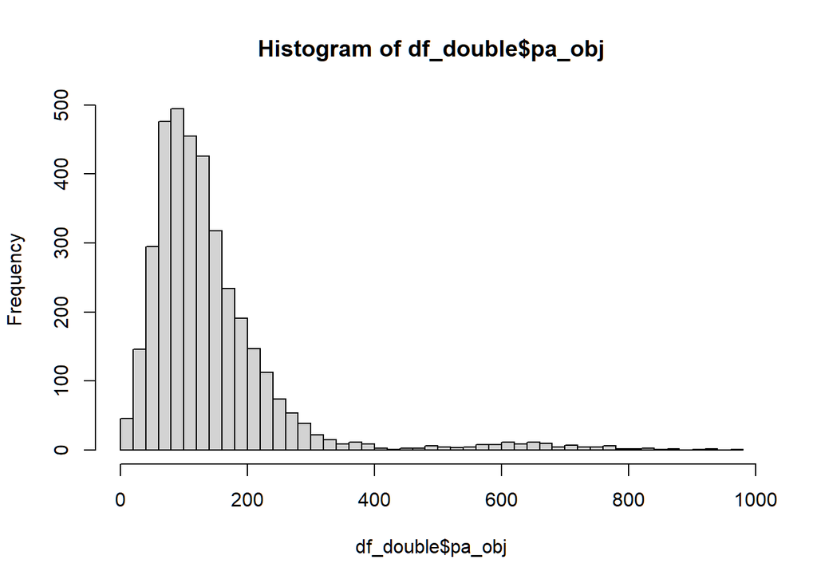

```r
hist(df_double$pa_obj, breaks = 50)
```

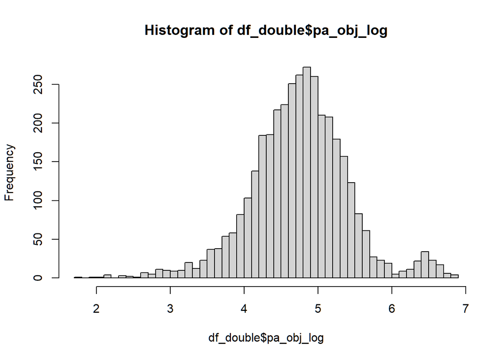

```r
df_double$pa_obj_log <- log(df_double$pa_obj)

hist(df_double$pa_obj_log, breaks = 50)
```

### Persuasion

```r
formula <- bf(
  pa_obj ~ 0 +
    is_A + is_B + # Intercepts
    is_A:persuasion_self_cw + is_B:persuasion_self_cw +
    is_A:persuasion_partner_cw + is_B:persuasion_partner_cw +

    is_A:persuasion_self_cb + is_B:persuasion_self_cb +
    is_A:persuasion_partner_cb + is_B:persuasion_partner_cb +

    #is_A:plan_self + is_B:plan_self +
    #is_A:plan_partner + is_B:plan_partner +
    is_A:day + is_B:day +

    is_A:weartime_self_cw + is_B:weartime_self_cw +
    is_A:weartime_self_cb + is_B:weartime_self_cb +

    # Random effects
    (0 +
    is_A + is_B + # Intercepts
    is_A:persuasion_self_cw + is_B:persuasion_self_cw +
    is_A:persuasion_partner_cw + is_B:persuasion_partner_cw |dd| coupleID)

  , decomp = 'QR'
  #, autocor = autocor_str
)



prior1 <- c(
  brms::set_prior("normal(0, 2.5)", class = "b")

  , brms::set_prior("normal(0, 50)", class = "b", coef = 'is_A')
  , brms::set_prior("normal(0, 50)", class = "b", coef = 'is_B')

  , brms::set_prior("normal(0, 2)", class = "sd", group = "coupleID", lb = 0)
  , brms::set_prior("student_t(3, 0, 2.5)", class = "sigma", lb = 0)
)


#brms::validate_prior(
#  prior1,
#  formula = formula,
#  data = df_double,
#  family = lognormal()
#  )

#df_minimal <- df_double[, c("AorB", all.vars(as.formula(formula)))]

pa_obj_log_persuasion <- my_brm(
  mi = use_mi,
  imputed_data = implist,

  formula = formula,
  prior = prior1,
  data = df_double,
  family = lognormal(),
  #control = list(adapt_delta = 0.95),
  iter = iterations,
  warmup = warmup,
  chains = 4,
  cores = 4,
  seed = 7777,
  file = file.path("models_cache_brms", paste0("pa_obj_log_gaussian_persuasion", suffix))
)
if (check_models) {
  check_brms(pa_obj_log_persuasion, log_pp_check = TRUE)
  DHARMa.check_brms.all(pa_obj_log_persuasion, integer = TRUE, outliers_type = 'bootstrap')
}
```

```r
# rope range for lognormal model
rope_factor <- sd(log(pa_obj_log_persuasion$data$pa_obj))
rope_range_log = c(-0.1 * rope_factor, 0.1 * rope_factor)

summary_pa_obj <- summarize_brms(
  pa_obj_log_persuasion,
  stats_to_report = stats_to_report,
  rope_range = rope_range_log,
  #model_rows_fixed = model_rows_fixed,
  #model_rows_random = model_rows_random,
  #model_rownames_fixed = model_rownames_fixed,
  #model_rownames_random = model_rownames_random,
  exponentiate = T)
```

```
## Model has no intercept. VIFs may not be sensible.
```

```r
summary_pa_obj %>%
  print_df(
    #rows_to_pack = rows_to_pack
    )
```

|  | exp(Est.) | SE | 95% CI | pd | ROPE | inside ROPE | Rhat | Bulk_ESS | Tail_ESS |
| --- | --- | --- | --- | --- | --- | --- | --- | --- | --- |
| is_A | 101.71*** | 6.22 | [ 89.97, 115.11] | 1.000 | [0.94, 1.07] | 0.000 | 1.003 | 951 | 1434 |
| is_B | 136.08*** | 7.27 | [122.13, 151.56] | 1.000 | [0.94, 1.07] | 0.000 | 1.005 | 1389 | 1918 |
| is_A:persuasion_self_cw | 1.05* | 0.02 | [ 1.01, 1.09] | 0.987 | [0.94, 1.07] | 0.843 | 1.000 | 3928 | 3337 |
| is_B:persuasion_self_cw | 1.01 | 0.02 | [ 0.97, 1.05] | 0.655 | [0.94, 1.07] | 0.997 | 1.001 | 3630 | 3130 |
| is_A:persuasion_partner_cw | 1.02 | 0.02 | [ 0.98, 1.06] | 0.796 | [0.94, 1.07] | 0.987 | 0.999 | 3459 | 3176 |
| is_B:persuasion_partner_cw | 1.03 | 0.02 | [ 0.99, 1.07] | 0.913 | [0.94, 1.07] | 0.964 | 1.000 | 3753 | 3537 |
| is_A:persuasion_self_cb | 1.25 | 0.22 | [ 0.87, 1.77] | 0.899 | [0.94, 1.07] | 0.128 | 1.004 | 994 | 1743 |
| is_B:persuasion_self_cb | 0.89 | 0.11 | [ 0.69, 1.13] | 0.837 | [0.94, 1.07] | 0.264 | 1.003 | 1266 | 1932 |
| is_A:persuasion_partner_cb | 0.89 | 0.14 | [ 0.67, 1.21] | 0.785 | [0.94, 1.07] | 0.244 | 1.004 | 1106 | 2003 |
| is_B:persuasion_partner_cb | 1.29 | 0.19 | [ 0.97, 1.76] | 0.960 | [0.94, 1.07] | 0.086 | 1.003 | 1153 | 2022 |
| is_A:day | 0.98 | 0.05 | [ 0.90, 1.08] | 0.626 | [0.94, 1.07] | 0.805 | 1.001 | 9420 | 2738 |
| is_B:day | 0.95 | 0.05 | [ 0.86, 1.04] | 0.856 | [0.94, 1.07] | 0.608 | 1.003 | 8586 | 2175 |
| is_A:weartime_self_cw | 1.00*** | 0.00 | [ 1.00, 1.00] | 1.000 | [0.94, 1.07] | 1.000 | 1.000 | 9905 | 3242 |
| is_B:weartime_self_cw | 1.00* | 0.00 | [ 1.00, 1.00] | 0.986 | [0.94, 1.07] | 1.000 | 1.002 | 7670 | 2893 |
| is_A:weartime_self_cb | 1.00 | 0.00 | [ 1.00, 1.00] | 0.702 | [0.94, 1.07] | 1.000 | 1.002 | 1124 | 1965 |
| is_B:weartime_self_cb | 1.00 | 0.00 | [ 1.00, 1.00] | 0.575 | [0.94, 1.07] | 1.000 | 1.001 | 1304 | 1992 |
| sd(is_A) | 0.34 | 0.04 | [0.27, 0.44] | NA | NA | NA | 1.001 | 1313 | 2072 |
| sd(is_B) | 0.29 | 0.04 | [0.22, 0.38] | NA | NA | NA | 1.001 | 1472 | 2002 |
| sd(is_A:persuasion_self_cw) | 0.06 | 0.02 | [0.01, 0.11] | NA | NA | NA | 1.006 | 851 | 503 |
| sd(is_B:persuasion_self_cw) | 0.06 | 0.02 | [0.02, 0.11] | NA | NA | NA | 1.002 | 1911 | 1806 |
| sd(is_A:persuasion_partner_cw) | 0.07 | 0.02 | [0.02, 0.13] | NA | NA | NA | 1.001 | 1384 | 1295 |
| sd(is_B:persuasion_partner_cw) | 0.07 | 0.03 | [0.01, 0.13] | NA | NA | NA | 1.002 | 1208 | 1198 |
| sigma | 0.55 | 0.01 | [0.53, 0.56] | NA | NA | NA | 1.000 | 8451 | 3220 |

### Pressure

```r
formula <- bf(
  pa_obj ~ 0 +
    is_A + is_B + # Intercepts
    is_A:pressure_self_cw + is_B:pressure_self_cw +
    is_A:pressure_partner_cw + is_B:pressure_partner_cw +

    is_A:pressure_self_cb + is_B:pressure_self_cb +
    is_A:pressure_partner_cb + is_B:pressure_partner_cb +

    #is_A:plan_self + is_B:plan_self +
    #is_A:plan_partner + is_B:plan_partner +
    is_A:day + is_B:day +

    is_A:weartime_self_cw + is_B:weartime_self_cw +
    is_A:weartime_self_cb + is_B:weartime_self_cb +

    # Random effects
    (0 +
    is_A + is_B + # Intercepts
    is_A:pressure_self_cw + is_B:pressure_self_cw +
    is_A:pressure_partner_cw + is_B:pressure_partner_cw |dd| coupleID)

  , decomp = 'QR'
  #, autocor = autocor_str
)



prior1 <- c(
  brms::set_prior("normal(0, 2.5)", class = "b")

  , brms::set_prior("normal(0, 50)", class = "b", coef = 'is_A')
  , brms::set_prior("normal(0, 50)", class = "b", coef = 'is_B')

  , brms::set_prior("normal(0, 2)", class = "sd", group = "coupleID", lb = 0)
  , brms::set_prior("student_t(3, 0, 2.5)", class = "sigma", lb = 0)
)


#brms::validate_prior(
#  prior1,
#  formula = formula,
#  data = df_double,
#  family = lognormal()
#  )

#df_minimal <- df_double[, c("AorB", all.vars(as.formula(formula)))]

pa_obj_log_pressure <- my_brm(
  mi = use_mi,
  imputed_data = implist,

  formula = formula,
  prior = prior1,
  data = df_double,
  family = lognormal(),
  #control = list(adapt_delta = 0.95),
  iter = iterations,
  warmup = warmup,
  chains = 4,
  cores = 4,
  seed = 7777,
  file = file.path("models_cache_brms", paste0("pa_obj_log_gaussian_pressure", suffix))
)
if (check_models) {
  check_brms(pa_obj_log_pressure, log_pp_check = TRUE)
  DHARMa.check_brms.all(pa_obj_log_pressure, integer = TRUE, outliers_type = 'bootstrap')
}
```

```r
# rope range for lognormal model
rope_factor <- sd(log(pa_obj_log_pressure$data$pa_obj))
rope_range_log = c(-0.1 * rope_factor, 0.1 * rope_factor)

summary_pa_obj <- summarize_brms(
  pa_obj_log_pressure,
  stats_to_report = stats_to_report,
  rope_range = rope_range_log,
  #model_rows_fixed = model_rows_fixed,
  #model_rows_random = model_rows_random,
  #model_rownames_fixed = model_rownames_fixed,
  #model_rownames_random = model_rownames_random,
  exponentiate = T)
```

```
## Model has no intercept. VIFs may not be sensible.
```

```
## Model has interaction terms. VIFs might be inflated.
##   You may check multicollinearity among predictors of a model without
##   interaction terms.
```

# Check for Multicollinearity

Low Correlation

```
                 Term  VIF     VIF 95% CI Increased SE Tolerance
                 is_A 1.90 [ 1.82,  1.99]         1.38      0.53
                 is_B 1.03 [ 1.01,  1.09]         1.01      0.97
is_A:pressure_self_cw 1.02 [ 1.00,  1.11]         1.01      0.98
is_B:pressure_self_cw 1.03 [ 1.01,  1.09]         1.01      0.97
```

Moderate Correlation

```
                 Term  VIF     VIF 95% CI Increased SE Tolerance
is_A:pressure_self_cb 8.76 [ 8.26,  9.29]         2.96      0.11
```

High Correlation

```
                 Term   VIF     VIF 95% CI Increased SE Tolerance
```

```r
summary_pa_obj %>%
  print_df(
    #rows_to_pack = rows_to_pack
    )
```

|  | exp(Est.) | SE | 95% CI | pd | ROPE | inside ROPE | Rhat | Bulk_ESS | Tail_ESS |
| --- | --- | --- | --- | --- | --- | --- | --- | --- | --- |
| is_A | 101.82*** | 6.29 | [ 90.01, 115.55] | 1.000 | [0.94, 1.07] | 0.000 | 1.001 | 760 | 1414 |
| is_B | 137.46*** | 7.80 | [123.29, 153.89] | 1.000 | [0.94, 1.07] | 0.000 | 1.001 | 939 | 2113 |
| is_A:pressure_self_cw | 0.99 | 0.05 | [ 0.87, 1.09] | 0.607 | [0.94, 1.07] | 0.760 | 1.001 | 3475 | 2940 |
| is_B:pressure_self_cw | 0.99 | 0.04 | [ 0.91, 1.08] | 0.609 | [0.94, 1.07] | 0.853 | 0.999 | 5396 | 3072 |
| is_A:pressure_partner_cw | 1.01 | 0.04 | [ 0.93, 1.09] | 0.600 | [0.94, 1.07] | 0.898 | 1.000 | 5928 | 3035 |
| is_B:pressure_partner_cw | 1.02 | 0.06 | [ 0.92, 1.16] | 0.665 | [0.94, 1.07] | 0.713 | 1.001 | 3788 | 2687 |
| is_A:pressure_self_cb | 0.85 | 0.29 | [ 0.43, 1.66] | 0.690 | [0.94, 1.07] | 0.132 | 1.004 | 1534 | 1963 |
| is_B:pressure_self_cb | 0.93 | 0.23 | [ 0.58, 1.53] | 0.618 | [0.94, 1.07] | 0.202 | 1.003 | 1593 | 2174 |
| is_A:pressure_partner_cb | 1.24 | 0.34 | [ 0.73, 2.15] | 0.791 | [0.94, 1.07] | 0.141 | 1.005 | 1437 | 2207 |
| is_B:pressure_partner_cb | 1.21 | 0.38 | [ 0.64, 2.23] | 0.726 | [0.94, 1.07] | 0.123 | 1.004 | 1678 | 2434 |
| is_A:day | 0.95 | 0.04 | [ 0.87, 1.04] | 0.851 | [0.94, 1.07] | 0.642 | 1.002 | 8015 | 3016 |
| is_B:day | 0.92 | 0.04 | [ 0.84, 1.01] | 0.964 | [0.94, 1.07] | 0.352 | 1.003 | 9930 | 2577 |
| is_A:weartime_self_cw | 1.00*** | 0.00 | [ 1.00, 1.00] | 1.000 | [0.94, 1.07] | 1.000 | 1.000 | 7074 | 2735 |
| is_B:weartime_self_cw | 1.00 | 0.00 | [ 1.00, 1.00] | 0.971 | [0.94, 1.07] | 1.000 | 1.001 | 8048 | 2482 |
| is_A:weartime_self_cb | 1.00 | 0.00 | [ 1.00, 1.00] | 0.626 | [0.94, 1.07] | 1.000 | 1.003 | 914 | 1459 |
| is_B:weartime_self_cb | 1.00 | 0.00 | [ 1.00, 1.00] | 0.718 | [0.94, 1.07] | 1.000 | 1.009 | 1187 | 2234 |
| sd(is_A) | 0.34 | 0.04 | [0.27, 0.44] | NA | NA | NA | 1.003 | 1060 | 1993 |
| sd(is_B) | 0.29 | 0.04 | [0.23, 0.39] | NA | NA | NA | 1.002 | 1455 | 2240 |
| sd(is_A:pressure_self_cw) | 0.08 | 0.07 | [0.00, 0.25] | NA | NA | NA | 1.000 | 1310 | 1811 |
| sd(is_B:pressure_self_cw) | 0.05 | 0.04 | [0.00, 0.18] | NA | NA | NA | 1.001 | 1935 | 1832 |
| sd(is_A:pressure_partner_cw) | 0.04 | 0.03 | [0.00, 0.13] | NA | NA | NA | 1.002 | 2463 | 1819 |
| sd(is_B:pressure_partner_cw) | 0.07 | 0.06 | [0.00, 0.26] | NA | NA | NA | 1.000 | 1722 | 1765 |
| sigma | 0.56 | 0.01 | [0.54, 0.57] | NA | NA | NA | 1.001 | 7882 | 2946 |

### Pushing

```r
formula <- bf(
  pa_obj ~ 0 +
    is_A + is_B + # Intercepts
    is_A:pushing_self_cw + is_B:pushing_self_cw +
    is_A:pushing_partner_cw + is_B:pushing_partner_cw +

    is_A:pushing_self_cb + is_B:pushing_self_cb +
    is_A:pushing_partner_cb + is_B:pushing_partner_cb +

    #is_A:plan_self + is_B:plan_self +
    #is_A:plan_partner + is_B:plan_partner +
    barriers_self_cw + barriers_self_cb +
    is_A:day + is_B:day +

    is_A:weartime_self_cw + is_B:weartime_self_cw +
    is_A:weartime_self_cb + is_B:weartime_self_cb +

    # Random effects
    (0 +
    is_A + is_B + # Intercepts
    is_A:pushing_self_cw + is_B:pushing_self_cw +
    is_A:pushing_partner_cw + is_B:pushing_partner_cw |dd| coupleID)

  , decomp = 'QR'
  #, autocor = autocor_str
)



prior1 <- c(
  brms::set_prior("normal(0, 2.5)", class = "b")

  , brms::set_prior("normal(0, 50)", class = "b", coef = 'is_A')
  , brms::set_prior("normal(0, 50)", class = "b", coef = 'is_B')

  , brms::set_prior("normal(0, 2)", class = "sd", group = "coupleID", lb = 0)
  , brms::set_prior("student_t(3, 0, 2.5)", class = "sigma", lb = 0)
)


#brms::validate_prior(
#  prior1,
#  formula = formula,
#  data = df_double,
#  family = lognormal()
#  )

#df_minimal <- df_double[, c("AorB", all.vars(as.formula(formula)))]

pa_obj_log_pushing <- my_brm(
  mi = use_mi,
  imputed_data = implist,

  formula = formula,
  prior = prior1,
  data = df_double,
  family = lognormal(),
  #control = list(adapt_delta = 0.95),
  iter = iterations,
  warmup = warmup,
  chains = 4,
  cores = 4,
  seed = 7777,
  file = file.path("models_cache_brms", paste0("pa_obj_log_gaussian_pushing", suffix))
)
if (check_models) {
  check_brms(pa_obj_log_pushing, log_pp_check = TRUE)
  DHARMa.check_brms.all(pa_obj_log_pushing, integer = TRUE, outliers_type = 'bootstrap')
}
```

```r
# rope range for lognormal model
rope_factor <- sd(log(pa_obj_log_pushing$data$pa_obj))
rope_range_log = c(-0.1 * rope_factor, 0.1 * rope_factor)

summary_pa_obj <- summarize_brms(
  pa_obj_log_pushing,
  stats_to_report = stats_to_report,
  rope_range = rope_range_log,
  #model_rows_fixed = model_rows_fixed,
  #model_rows_random = model_rows_random,
  #model_rownames_fixed = model_rownames_fixed,
  #model_rownames_random = model_rownames_random,
  exponentiate = T)
```

```
## Model has no intercept. VIFs may not be sensible.
```

```r
summary_pa_obj %>%
  print_df(
    #rows_to_pack = rows_to_pack
    )
```

|  | exp(Est.) | SE | 95% CI | pd | ROPE | inside ROPE | Rhat | Bulk_ESS | Tail_ESS |
| --- | --- | --- | --- | --- | --- | --- | --- | --- | --- |
| is_A | 105.88*** | 7.43 | [ 91.90, 120.99] | 1.000 | [0.94, 1.06] | 0.000 | 1.001 | 1692 | 2113 |
| is_B | 149.27*** | 10.28 | [130.58, 170.95] | 1.000 | [0.94, 1.06] | 0.000 | 1.001 | 2102 | 2131 |
| barriers_self_cw | 1.04*** | 0.01 | [ 1.02, 1.06] | 1.000 | [0.94, 1.06] | 0.997 | 1.000 | 10206 | 2393 |
| barriers_self_cb | 1.08 | 0.05 | [ 0.98, 1.18] | 0.947 | [0.94, 1.06] | 0.388 | 1.001 | 1815 | 2464 |
| is_A:pushing_self_cw | 1.07 | 0.04 | [ 1.00, 1.16] | 0.968 | [0.94, 1.06] | 0.403 | 1.001 | 4288 | 3323 |
| is_B:pushing_self_cw | 1.00 | 0.03 | [ 0.94, 1.06] | 0.501 | [0.94, 1.06] | 0.956 | 1.001 | 4995 | 3238 |
| is_A:pushing_partner_cw | 0.99 | 0.03 | [ 0.94, 1.04] | 0.690 | [0.94, 1.06] | 0.967 | 1.003 | 5581 | 2581 |
| is_B:pushing_partner_cw | 1.07 | 0.04 | [ 0.99, 1.14] | 0.965 | [0.94, 1.06] | 0.473 | 1.002 | 4694 | 3113 |
| is_A:pushing_self_cb | 1.02 | 0.31 | [ 0.55, 1.85] | 0.521 | [0.94, 1.06] | 0.160 | 1.003 | 1653 | 2296 |
| is_B:pushing_self_cb | 0.93 | 0.29 | [ 0.50, 1.77] | 0.598 | [0.94, 1.06] | 0.152 | 1.000 | 1906 | 2595 |
| is_A:pushing_partner_cb | 1.14 | 0.37 | [ 0.59, 2.17] | 0.663 | [0.94, 1.06] | 0.137 | 1.001 | 1528 | 1877 |
| is_B:pushing_partner_cb | 1.47 | 0.44 | [ 0.82, 2.68] | 0.906 | [0.94, 1.06] | 0.070 | 1.001 | 1911 | 2247 |
| is_A:day | 1.01 | 0.07 | [ 0.89, 1.15] | 0.529 | [0.94, 1.06] | 0.654 | 1.000 | 9052 | 3054 |
| is_B:day | 0.88* | 0.06 | [ 0.78, 1.00] | 0.978 | [0.94, 1.06] | 0.156 | 1.001 | 9018 | 2726 |
| is_A:weartime_self_cw | 1.00** | 0.00 | [ 1.00, 1.00] | 0.999 | [0.94, 1.06] | 1.000 | 1.000 | 6867 | 3110 |
| is_B:weartime_self_cw | 1.00* | 0.00 | [ 1.00, 1.00] | 0.991 | [0.94, 1.06] | 1.000 | 1.000 | 8525 | 2873 |
| is_A:weartime_self_cb | 1.00 | 0.00 | [ 1.00, 1.00] | 0.717 | [0.94, 1.06] | 1.000 | 1.003 | 1783 | 2405 |
| is_B:weartime_self_cb | 1.00 | 0.00 | [ 1.00, 1.00] | 0.837 | [0.94, 1.06] | 1.000 | 1.002 | 2430 | 2599 |
| sd(is_A) | 0.34 | 0.05 | [0.26, 0.46] | NA | NA | NA | 1.000 | 1747 | 2463 |
| sd(is_B) | 0.33 | 0.05 | [0.25, 0.44] | NA | NA | NA | 1.000 | 2071 | 2637 |
| sd(is_A:pushing_self_cw) | 0.10 | 0.05 | [0.01, 0.21] | NA | NA | NA | 1.002 | 1298 | 1591 |
| sd(is_B:pushing_self_cw) | 0.09 | 0.04 | [0.01, 0.17] | NA | NA | NA | 1.003 | 1154 | 1024 |
| sd(is_A:pushing_partner_cw) | 0.03 | 0.03 | [0.00, 0.09] | NA | NA | NA | 1.000 | 2582 | 2404 |
| sd(is_B:pushing_partner_cw) | 0.09 | 0.04 | [0.02, 0.18] | NA | NA | NA | 1.002 | 2104 | 1819 |
| sigma | 0.52 | 0.01 | [0.50, 0.54] | NA | NA | NA | 1.000 | 6753 | 2965 |

## Affect

```r
range(df_double$aff, na.rm = T)
```

```
## [1] 0 5
```

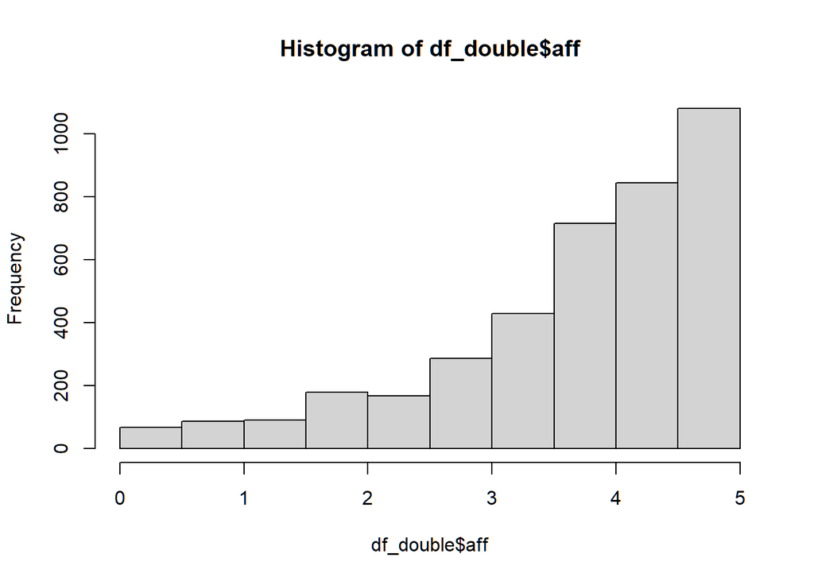

```r
hist(df_double$aff, breaks = 15)
```

### Persuasion

```r
formula <- bf(
  aff ~ 0 +
    is_A + is_B + # Intercepts
    is_A:persuasion_self_cw + is_B:persuasion_self_cw +
    is_A:persuasion_partner_cw + is_B:persuasion_partner_cw +

    is_A:persuasion_self_cb + is_B:persuasion_self_cb +
    is_A:persuasion_partner_cb + is_B:persuasion_partner_cb +

    #is_A:plan_self + is_B:plan_self +
    #is_A:plan_partner + is_B:plan_partner +
    is_A:day + is_B:day +

    # Random effects
    (0 +
    is_A + is_B + # Intercepts
    is_A:pushing_self_cw + is_B:pushing_self_cw +
    is_A:pushing_partner_cw + is_B:pushing_partner_cw |dd| coupleID)

  , decomp = 'QR'
  #, autocor = autocor_str
)


prior1 <- c(
  brms::set_prior("normal(0, 5)", class = "b")

  , brms::set_prior("normal(0, 20)", class = "b", coef = 'is_A')
  , brms::set_prior("normal(0, 20)", class = "b", coef = 'is_B')

  , brms::set_prior("normal(0, 2)", class = "sd", group = "coupleID", lb = 0)
  , brms::set_prior("student_t(3, 0, 2.5)", class = "sigma", lb = 0)
)

#brms::validate_prior(
#  prior1,
#  formula = formula,
#  data = df_double,
#  family = gaussian()
#  )

#df_minimal <- df_double[, c("AorB", all.vars(as.formula(formula)))]

mood_gauss_persuasion <- my_brm(
  mi = use_mi,
  imputed_data = implist,

  formula = formula,
  prior = prior1,
  data = df_double,
  family = gaussian(),
  #control = list(adapt_delta = 0.95, max_treedepth = 15),
  iter = iterations,
  warmup = warmup,
  chains = 4,
  cores = 4,
  seed = 7777,
  file = file.path("models_cache_brms", paste0("mood_gauss_persuasion", suffix))
)
if (check_models) {
  check_brms(mood_gauss_persuasion, log_pp_check = FALSE)
  DHARMa.check_brms.all(mood_gauss_persuasion, integer = FALSE)
}
```

```r
summary_mood <- summarize_brms(
  mood_gauss_persuasion,
  stats_to_report = stats_to_report,
  #model_rows_fixed = model_rows_fixed,
  #model_rows_random = model_rows_random,
  #model_rownames_fixed = model_rownames_fixed,
  #model_rownames_random = model_rownames_random,
  exponentiate = F)
```

```
## Model has no intercept. VIFs may not be sensible.
```

```r
summary_mood %>%
  print_df(
    #rows_to_pack = rows_to_pack
    )
```

|  | Est. | SE | 95% CI | pd | ROPE | inside ROPE | Rhat | Bulk_ESS | Tail_ESS |
| --- | --- | --- | --- | --- | --- | --- | --- | --- | --- |
| is_A | 3.61*** | 0.12 | [ 3.37, 3.84] | 1.000 | [-0.11, 0.11] | 0.000 | 1.002 | 453 | 899 |
| is_B | 3.87*** | 0.14 | [ 3.61, 4.16] | 1.000 | [-0.11, 0.11] | 0.000 | 1.010 | 446 | 1023 |
| is_A:persuasion_self_cw | 0.01 | 0.02 | [-0.04, 0.05] | 0.634 | [-0.11, 0.11] | 1.000 | 1.000 | 5822 | 3143 |
| is_B:persuasion_self_cw | -0.01 | 0.02 | [-0.06, 0.03] | 0.708 | [-0.11, 0.11] | 1.000 | 1.001 | 5420 | 2727 |
| is_A:persuasion_partner_cw | 0.05* | 0.02 | [ 0.00, 0.09] | 0.980 | [-0.11, 0.11] | 0.998 | 1.000 | 5603 | 2712 |
| is_B:persuasion_partner_cw | 0.01 | 0.02 | [-0.04, 0.05] | 0.633 | [-0.11, 0.11] | 1.000 | 1.000 | 5288 | 3058 |
| is_A:persuasion_self_cb | -0.27 | 0.32 | [-0.90, 0.39] | 0.797 | [-0.11, 0.11] | 0.190 | 1.002 | 571 | 957 |
| is_B:persuasion_self_cb | 0.38 | 0.33 | [-0.31, 1.02] | 0.868 | [-0.11, 0.11] | 0.142 | 1.003 | 672 | 1116 |
| is_A:persuasion_partner_cb | 0.39 | 0.27 | [-0.18, 0.92] | 0.917 | [-0.11, 0.11] | 0.120 | 1.003 | 583 | 1141 |
| is_B:persuasion_partner_cb | -0.20 | 0.39 | [-0.97, 0.58] | 0.701 | [-0.11, 0.11] | 0.206 | 1.005 | 672 | 1191 |
| is_A:day | 0.45*** | 0.07 | [ 0.31, 0.59] | 1.000 | [-0.11, 0.11] | 0.000 | 1.000 | 4830 | 2774 |
| is_B:day | 0.08 | 0.07 | [-0.05, 0.22] | 0.874 | [-0.11, 0.11] | 0.656 | 1.000 | 5104 | 3328 |
| sd(is_A) | 0.70 | 0.09 | [0.55, 0.90] | NA | NA | NA | 1.011 | 605 | 1204 |
| sd(is_B) | 0.79 | 0.10 | [0.63, 1.03] | NA | NA | NA | 1.009 | 774 | 1225 |
| sd(is_A:pushing_self_cw) | 0.11 | 0.06 | [0.01, 0.24] | NA | NA | NA | 1.009 | 1039 | 1100 |
| sd(is_B:pushing_self_cw) | 0.06 | 0.05 | [0.00, 0.18] | NA | NA | NA | 1.002 | 1271 | 1356 |
| sd(is_A:pushing_partner_cw) | 0.13 | 0.05 | [0.03, 0.24] | NA | NA | NA | 1.007 | 732 | 301 |
| sd(is_B:pushing_partner_cw) | 0.12 | 0.06 | [0.01, 0.25] | NA | NA | NA | 1.003 | 1411 | 1092 |
| sigma | 0.87 | 0.01 | [0.85, 0.89] | NA | NA | NA | 1.000 | 5092 | 2948 |

### Pressure

```r
formula <- bf(
  aff ~ 0 +
    is_A + is_B + # Intercepts
    is_A:pressure_self_cw + is_B:pressure_self_cw +
    is_A:pressure_partner_cw + is_B:pressure_partner_cw +

    is_A:pressure_self_cb + is_B:pressure_self_cb +
    is_A:pressure_partner_cb + is_B:pressure_partner_cb +

    #is_A:plan_self + is_B:plan_self +
    #is_A:plan_partner + is_B:plan_partner +
    is_A:day + is_B:day +

    # Random effects
    (0 +
    is_A + is_B + # Intercepts
    is_A:pushing_self_cw + is_B:pushing_self_cw +
    is_A:pushing_partner_cw + is_B:pushing_partner_cw |dd| coupleID)

  , decomp = 'QR'
  #, autocor = autocor_str
)


prior1 <- c(
  brms::set_prior("normal(0, 5)", class = "b")

  , brms::set_prior("normal(0, 20)", class = "b", coef = 'is_A')
  , brms::set_prior("normal(0, 20)", class = "b", coef = 'is_B')

  , brms::set_prior("normal(0, 2)", class = "sd", group = "coupleID", lb = 0)
  , brms::set_prior("student_t(3, 0, 2.5)", class = "sigma", lb = 0)
)

#brms::validate_prior(
#  prior1,
#  formula = formula,
#  data = df_double,
#  family = gaussian()
#  )

#df_minimal <- df_double[, c("AorB", all.vars(as.formula(formula)))]

mood_gauss_pressure <- my_brm(
  mi = use_mi,
  imputed_data = implist,

  formula = formula,
  prior = prior1,
  data = df_double,
  family = gaussian(),
  #control = list(adapt_delta = 0.95, max_treedepth = 15),
  iter = iterations,
  warmup = warmup,
  chains = 4,
  cores = 4,
  seed = 7777,
  file = file.path("models_cache_brms", paste0("mood_gauss_pressure", suffix))
)
if (check_models) {
  check_brms(mood_gauss_pressure, log_pp_check = FALSE)
  DHARMa.check_brms.all(mood_gauss_pressure, integer = FALSE)
}
```

```r
summary_mood <- summarize_brms(
  mood_gauss_pressure,
  stats_to_report = stats_to_report,
  #model_rows_fixed = model_rows_fixed,
  #model_rows_random = model_rows_random,
  #model_rownames_fixed = model_rownames_fixed,
  #model_rownames_random = model_rownames_random,
  exponentiate = F)
```

```
## Model has no intercept. VIFs may not be sensible.
```

```r
summary_mood %>%
  print_df(
    #rows_to_pack = rows_to_pack
    )
```

|  | Est. | SE | 95% CI | pd | ROPE | inside ROPE | Rhat | Bulk_ESS | Tail_ESS |
| --- | --- | --- | --- | --- | --- | --- | --- | --- | --- |
| is_A | 3.63*** | 0.14 | [ 3.35, 3.90] | 1.000 | [-0.11, 0.11] | 0.000 | 1.020 | 198 | 409 |
| is_B | 3.87*** | 0.14 | [ 3.58, 4.16] | 1.000 | [-0.11, 0.11] | 0.000 | 1.018 | 233 | 687 |
| is_A:pressure_self_cw | -0.06 | 0.06 | [-0.17, 0.06] | 0.844 | [-0.11, 0.11] | 0.841 | 1.001 | 6955 | 3236 |
| is_B:pressure_self_cw | 0.01 | 0.06 | [-0.11, 0.11] | 0.542 | [-0.11, 0.11] | 0.960 | 1.001 | 4185 | 3236 |
| is_A:pressure_partner_cw | 0.05 | 0.06 | [-0.06, 0.16] | 0.809 | [-0.11, 0.11] | 0.877 | 1.002 | 3919 | 3108 |
| is_B:pressure_partner_cw | 0.04 | 0.06 | [-0.07, 0.15] | 0.752 | [-0.11, 0.11] | 0.900 | 1.000 | 7136 | 2748 |
| is_A:pressure_self_cb | -0.18 | 0.67 | [-1.51, 1.16] | 0.602 | [-0.11, 0.11] | 0.125 | 1.001 | 994 | 1789 |
| is_B:pressure_self_cb | 0.11 | 0.57 | [-1.02, 1.27] | 0.581 | [-0.11, 0.11] | 0.168 | 1.007 | 1017 | 1699 |
| is_A:pressure_partner_cb | 0.23 | 0.52 | [-0.78, 1.28] | 0.675 | [-0.11, 0.11] | 0.157 | 1.003 | 1025 | 1644 |
| is_B:pressure_partner_cb | -0.12 | 0.73 | [-1.59, 1.29] | 0.570 | [-0.11, 0.11] | 0.127 | 1.005 | 977 | 1542 |
| is_A:day | 0.41*** | 0.07 | [ 0.27, 0.55] | 1.000 | [-0.11, 0.11] | 0.000 | 1.000 | 5190 | 2993 |
| is_B:day | 0.09 | 0.07 | [-0.05, 0.23] | 0.899 | [-0.11, 0.11] | 0.642 | 1.001 | 5465 | 3359 |
| sd(is_A) | 0.71 | 0.09 | [0.56, 0.93] | NA | NA | NA | 1.009 | 432 | 926 |
| sd(is_B) | 0.81 | 0.10 | [0.63, 1.05] | NA | NA | NA | 1.005 | 610 | 888 |
| sd(is_A:pushing_self_cw) | 0.12 | 0.06 | [0.01, 0.25] | NA | NA | NA | 1.002 | 814 | 588 |
| sd(is_B:pushing_self_cw) | 0.06 | 0.05 | [0.00, 0.18] | NA | NA | NA | 1.003 | 1108 | 1004 |
| sd(is_A:pushing_partner_cw) | 0.13 | 0.05 | [0.04, 0.24] | NA | NA | NA | 1.002 | 1571 | 1131 |
| sd(is_B:pushing_partner_cw) | 0.12 | 0.06 | [0.02, 0.25] | NA | NA | NA | 1.002 | 1430 | 1166 |
| sigma | 0.87 | 0.01 | [0.85, 0.89] | NA | NA | NA | 1.001 | 5267 | 3080 |

### pushing

```r
formula <- bf(
  aff ~ 0 +
    is_A + is_B + # Intercepts
    is_A:pushing_self_cw + is_B:pushing_self_cw +
    is_A:pushing_partner_cw + is_B:pushing_partner_cw +

    is_A:pushing_self_cb + is_B:pushing_self_cb +
    is_A:pushing_partner_cb + is_B:pushing_partner_cb +

    #is_A:plan_self + is_B:plan_self +
    #is_A:plan_partner + is_B:plan_partner +
    barriers_self_cw + barriers_self_cb +
    is_A:day + is_B:day +

    # Random effects
    (0 +
    is_A + is_B + # Intercepts
    is_A:pushing_self_cw + is_B:pushing_self_cw +
    is_A:pushing_partner_cw + is_B:pushing_partner_cw |dd| coupleID)

  , decomp = 'QR'
  #, autocor = autocor_str
)


prior1 <- c(
  brms::set_prior("normal(0, 5)", class = "b")

  , brms::set_prior("normal(0, 20)", class = "b", coef = 'is_A')
  , brms::set_prior("normal(0, 20)", class = "b", coef = 'is_B')

  , brms::set_prior("normal(0, 2)", class = "sd", group = "coupleID", lb = 0)
  , brms::set_prior("student_t(3, 0, 2.5)", class = "sigma", lb = 0)
)

#brms::validate_prior(
#  prior1,
#  formula = formula,
#  data = df_double,
#  family = gaussian()
#  )

#df_minimal <- df_double[, c("AorB", all.vars(as.formula(formula)))]

mood_gauss_pushing <- my_brm(
  mi = use_mi,
  imputed_data = implist,

  formula = formula,
  prior = prior1,
  data = df_double,
  family = gaussian(),
  #control = list(adapt_delta = 0.95, max_treedepth = 15),
  iter = iterations,
  warmup = warmup,
  chains = 4,
  cores = 4,
  seed = 7777,
  file = file.path("models_cache_brms", paste0("mood_gauss_pushing", suffix))
)
if (check_models) {
  check_brms(mood_gauss_pushing, log_pp_check = FALSE)
  DHARMa.check_brms.all(mood_gauss_pushing, integer = FALSE)
}
```

```r
summary_mood <- summarize_brms(
  mood_gauss_pushing,
  stats_to_report = stats_to_report,
  #model_rows_fixed = model_rows_fixed,
  #model_rows_random = model_rows_random,
  #model_rownames_fixed = model_rownames_fixed,
  #model_rownames_random = model_rownames_random,
  exponentiate = F)
```

```
## Model has no intercept. VIFs may not be sensible.
```

```r
summary_mood %>%
  print_df(
    #rows_to_pack = rows_to_pack
    )
```

|  | Est. | SE | 95% CI | pd | ROPE | inside ROPE | Rhat | Bulk_ESS | Tail_ESS |
| --- | --- | --- | --- | --- | --- | --- | --- | --- | --- |
| is_A | 3.64*** | 0.13 | [ 3.39, 3.89] | 1.000 | [-0.11, 0.11] | 0.000 | 1.005 | 593 | 1297 |
| is_B | 3.88*** | 0.14 | [ 3.62, 4.17] | 1.000 | [-0.11, 0.11] | 0.000 | 1.007 | 777 | 1375 |
| barriers_self_cw | 0.13*** | 0.01 | [ 0.10, 0.16] | 1.000 | [-0.11, 0.11] | 0.090 | 1.001 | 7427 | 2983 |
| barriers_self_cb | 0.23* | 0.10 | [ 0.03, 0.44] | 0.988 | [-0.11, 0.11] | 0.128 | 1.004 | 668 | 1454 |
| is_A:pushing_self_cw | 0.09 | 0.04 | [-0.01, 0.18] | 0.965 | [-0.11, 0.11] | 0.697 | 1.001 | 3486 | 2909 |
| is_B:pushing_self_cw | -0.02 | 0.04 | [-0.09, 0.06] | 0.680 | [-0.11, 0.11] | 0.989 | 1.001 | 5139 | 3007 |
| is_A:pushing_partner_cw | 0.10* | 0.04 | [ 0.01, 0.18] | 0.981 | [-0.11, 0.11] | 0.644 | 1.000 | 3407 | 2579 |
| is_B:pushing_partner_cw | 0.13* | 0.05 | [ 0.02, 0.23] | 0.989 | [-0.11, 0.11] | 0.362 | 1.000 | 3294 | 2957 |
| is_A:pushing_self_cb | -0.11 | 0.49 | [-1.13, 0.87] | 0.593 | [-0.11, 0.11] | 0.178 | 1.002 | 1046 | 1594 |
| is_B:pushing_self_cb | 0.77 | 0.66 | [-0.63, 2.02] | 0.870 | [-0.11, 0.11] | 0.062 | 1.002 | 904 | 1458 |
| is_A:pushing_partner_cb | 0.69 | 0.53 | [-0.38, 1.78] | 0.902 | [-0.11, 0.11] | 0.070 | 1.002 | 881 | 1260 |
| is_B:pushing_partner_cb | -0.29 | 0.60 | [-1.47, 0.96] | 0.680 | [-0.11, 0.11] | 0.123 | 1.007 | 955 | 2061 |
| is_A:day | 0.37*** | 0.10 | [ 0.17, 0.57] | 1.000 | [-0.11, 0.11] | 0.004 | 1.001 | 6560 | 2854 |
| is_B:day | 0.06 | 0.09 | [-0.12, 0.24] | 0.739 | [-0.11, 0.11] | 0.664 | 1.002 | 6084 | 3202 |
| sd(is_A) | 0.64 | 0.08 | [0.50, 0.85] | NA | NA | NA | 1.006 | 1032 | 1484 |
| sd(is_B) | 0.77 | 0.10 | [0.61, 1.02] | NA | NA | NA | 1.003 | 1043 | 1411 |
| sd(is_A:pushing_self_cw) | 0.09 | 0.06 | [0.01, 0.23] | NA | NA | NA | 1.003 | 1249 | 1529 |
| sd(is_B:pushing_self_cw) | 0.07 | 0.06 | [0.00, 0.20] | NA | NA | NA | 1.002 | 1397 | 1392 |
| sd(is_A:pushing_partner_cw) | 0.11 | 0.06 | [0.01, 0.24] | NA | NA | NA | 1.002 | 1236 | 1336 |
| sd(is_B:pushing_partner_cw) | 0.11 | 0.07 | [0.01, 0.27] | NA | NA | NA | 1.001 | 1327 | 1338 |
| sigma | 0.83 | 0.01 | [0.80, 0.86] | NA | NA | NA | 1.000 | 6693 | 3220 |

## Reactance

```r
range(df_double$reactance, na.rm = T)
```

```
## [1] 0 5
```

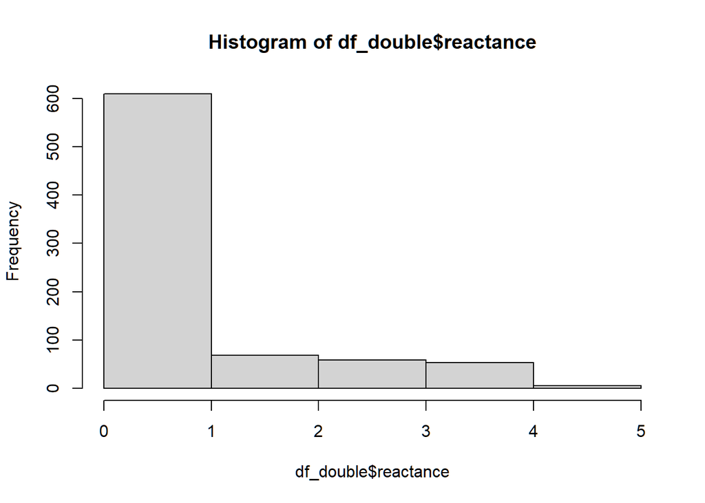

```r
hist(df_double$reactance, breaks = 7)
```

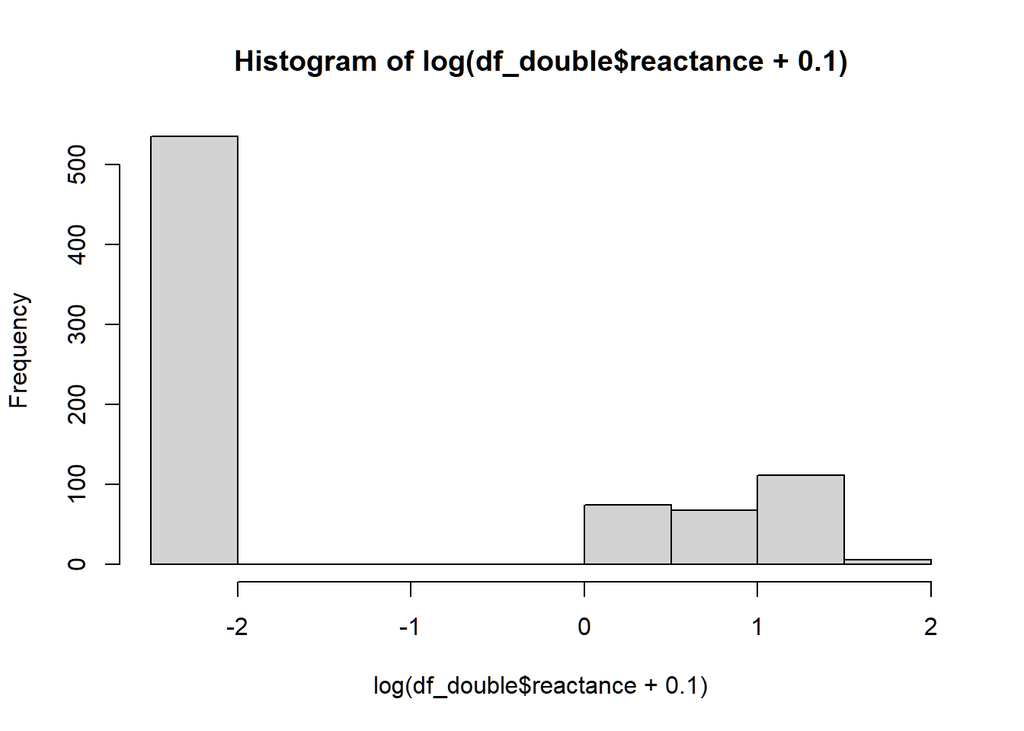

```r
hist(log(df_double$reactance+0.1), breaks = 10)
```

```r
introduce_binary_reactance <- function(data) {
  data$is_reactance <- factor(data$reactance > 0, levels = c(FALSE, TRUE), labels = c(0, 1))
  return(data)
}

df_double <- introduce_binary_reactance(df_double)
if (use_mi) {
  for (i in seq_along(implist)) {
    implist[[i]] <- introduce_binary_reactance(implist[[i]])
  }
}
```

### Persuasion

```r
formula <- bf(
  is_reactance ~ 0 +
    is_A + is_B + # Intercepts
    is_A:persuasion_self_cw + is_B:persuasion_self_cw +
    is_A:persuasion_partner_cw + is_B:persuasion_partner_cw +

    is_A:persuasion_self_cb + is_B:persuasion_self_cb +
    is_A:persuasion_partner_cb + is_B:persuasion_partner_cb +

    #is_A:plan_self + is_B:plan_self +
    #is_A:plan_partner + is_B:plan_partner +
    is_A:day + is_B:day +

    # Random effects
    (0 +
    is_A + is_B + # Intercepts
    is_A:persuasion_self_cw + is_B:persuasion_self_cw +
    is_A:persuasion_partner_cw + is_B:persuasion_partner_cw |dd| coupleID)

  , decomp = 'QR'
  #, autocor = autocor_str
  )



prior1 <- c(
  brms::set_prior("normal(0, 2.5)", class = "b")

  , brms::set_prior("normal(0, 10)", class = "b", coef = 'is_A')
  , brms::set_prior("normal(0, 10)", class = "b", coef = 'is_B')

  , brms::set_prior("normal(0, 2)", class = "sd", group = "coupleID", lb = 0)
)


#brms::validate_prior(
#  prior1,
#  formula = formula,
#  data = df_double,
#  family = bernoulli()
#  )



#df_minimal <- df_double[, c("AorB", all.vars(as.formula(formula)))]

is_reactance_persuasion <- my_brm(
  mi = use_mi,
  imputed_data = implist,

  formula = formula,
  prior = prior1,
  data = df_double,
  family = brms::bernoulli(),
  #control = list(adapt_delta = 0.95, max_treedepth = 15),
  iter = iterations,
  warmup = warmup,
  chains = 4,
  cores = 4,
  seed = 7777,
  file = file.path("models_cache_brms", paste0("is_reactance_persuasion", suffix))
  #, file_refit = 'always'
)
if (check_models) {
  check_brms(is_reactance_persuasion)
  DHARMa.check_brms.all(is_reactance_persuasion, integer = FALSE)
}
```

```r
summary_is_reactance <- summarize_brms(
  is_reactance_persuasion,
  stats_to_report = stats_to_report,
  #model_rows_fixed = model_rows_fixed,
  #model_rows_random = model_rows_random,
  #model_rownames_fixed = model_rownames_fixed,
  #model_rownames_random = model_rownames_random,
  exponentiate = T)
```

```
## Model has no intercept. VIFs may not be sensible.
```

```r
summary_is_reactance %>%
  print_df(
    #rows_to_pack = rows_to_pack
    )
```

|  | OR | SE | 95% CI | pd | ROPE | inside ROPE | Rhat | Bulk_ESS | Tail_ESS |
| --- | --- | --- | --- | --- | --- | --- | --- | --- | --- |
| is_A | 0.18*** | 0.09 | [0.06, 0.42] | 1.000 | [0.83, 1.20] | 0.000 | 1.000 | 2614 | 2734 |
| is_B | 0.29** | 0.12 | [0.12, 0.64] | 0.999 | [0.83, 1.20] | 0.005 | 1.001 | 3369 | 3196 |
| is_A:persuasion_self_cw | 0.90 | 0.13 | [0.64, 1.17] | 0.769 | [0.83, 1.20] | 0.681 | 1.001 | 2236 | 2875 |
| is_B:persuasion_self_cw | 0.78 | 0.11 | [0.54, 1.02] | 0.965 | [0.83, 1.20] | 0.308 | 1.000 | 3027 | 2084 |
| is_A:persuasion_partner_cw | 0.88 | 0.17 | [0.59, 1.28] | 0.740 | [0.83, 1.20] | 0.573 | 1.001 | 3281 | 2419 |
| is_B:persuasion_partner_cw | 1.26 | 0.24 | [0.85, 1.93] | 0.889 | [0.83, 1.20] | 0.370 | 1.001 | 2604 | 2514 |
| is_A:persuasion_self_cb | 5.18 | 4.43 | [0.95, 36.77] | 0.970 | [0.83, 1.20] | 0.029 | 1.001 | 1970 | 2558 |
| is_B:persuasion_self_cb | 2.81 | 2.20 | [0.58, 14.93] | 0.905 | [0.83, 1.20] | 0.074 | 1.002 | 1937 | 2597 |
| is_A:persuasion_partner_cb | 1.54 | 1.10 | [0.39, 8.13] | 0.734 | [0.83, 1.20] | 0.175 | 1.002 | 1658 | 1952 |
| is_B:persuasion_partner_cb | 2.01 | 1.82 | [0.33, 14.67] | 0.784 | [0.83, 1.20] | 0.120 | 1.000 | 2156 | 2685 |
| is_A:day | 2.54 | 1.40 | [0.88, 7.62] | 0.959 | [0.83, 1.20] | 0.061 | 1.001 | 5826 | 3180 |
| is_B:day | 1.04 | 0.58 | [0.34, 3.16] | 0.528 | [0.83, 1.20] | 0.248 | 1.003 | 5441 | 2933 |
| sd(is_A) | 1.37 | 0.42 | [0.67, 2.43] | NA | NA | NA | 1.006 | 1215 | 1900 |
| sd(is_B) | 1.37 | 0.33 | [0.84, 2.17] | NA | NA | NA | 1.000 | 2191 | 2654 |
| sd(is_A:persuasion_self_cw) | 0.30 | 0.18 | [0.02, 0.71] | NA | NA | NA | 1.003 | 794 | 963 |
| sd(is_B:persuasion_self_cw) | 0.35 | 0.26 | [0.02, 0.95] | NA | NA | NA | 1.002 | 797 | 1734 |
| sd(is_A:persuasion_partner_cw) | 0.48 | 0.27 | [0.05, 1.16] | NA | NA | NA | 1.002 | 1413 | 1509 |
| sd(is_B:persuasion_partner_cw) | 0.64 | 0.28 | [0.17, 1.37] | NA | NA | NA | 1.003 | 1425 | 1048 |

### Pressure

```r
formula <- bf(
  is_reactance ~ 0 +
    is_A + is_B + # Intercepts
    is_A:pressure_self_cw + is_B:pressure_self_cw +
    is_A:pressure_partner_cw + is_B:pressure_partner_cw +

    is_A:pressure_self_cb + is_B:pressure_self_cb +
    is_A:pressure_partner_cb + is_B:pressure_partner_cb +

    #is_A:plan_self + is_B:plan_self +
    #is_A:plan_partner + is_B:plan_partner +
    is_A:day + is_B:day +

    # Random effects
    (0 +
    is_A + is_B + # Intercepts
    is_A:pressure_self_cw + is_B:pressure_self_cw +
    is_A:pressure_partner_cw + is_B:pressure_partner_cw |dd| coupleID)

  , decomp = 'QR'
  #, autocor = autocor_str
  )



prior1 <- c(
  brms::set_prior("normal(0, 2.5)", class = "b")

  , brms::set_prior("normal(0, 10)", class = "b", coef = 'is_A')
  , brms::set_prior("normal(0, 10)", class = "b", coef = 'is_B')

  , brms::set_prior("normal(0, 2)", class = "sd", group = "coupleID", lb = 0)
)


#brms::validate_prior(
#  prior1,
#  formula = formula,
#  data = df_double,
#  family = bernoulli()
#  )



#df_minimal <- df_double[, c("AorB", all.vars(as.formula(formula)))]

is_reactance_pressure <- my_brm(
  mi = use_mi,
  imputed_data = implist,

  formula = formula,
  prior = prior1,
  data = df_double,
  family = brms::bernoulli(),
  #control = list(adapt_delta = 0.95, max_treedepth = 15),
  iter = iterations,
  warmup = warmup,
  chains = 4,
  cores = 4,
  seed = 7777,
  file = file.path("models_cache_brms", paste0("is_reactance_pressure", suffix))
  #, file_refit = 'always'
)
if (check_models) {
  check_brms(is_reactance_pressure)
  DHARMa.check_brms.all(is_reactance_pressure, integer = FALSE)
}
```

```r
summary_is_reactance <- summarize_brms(
  is_reactance_pressure,
  stats_to_report = stats_to_report,
  #model_rows_fixed = model_rows_fixed,
  #model_rows_random = model_rows_random,
  #model_rownames_fixed = model_rownames_fixed,
  #model_rownames_random = model_rownames_random,
  exponentiate = T)
```

```
## Model has no intercept. VIFs may not be sensible.
```

```r
summary_is_reactance %>%
  print_df(
    #rows_to_pack = rows_to_pack
    )
```

|  | OR | SE | 95% CI | pd | ROPE | inside ROPE | Rhat | Bulk_ESS | Tail_ESS |
| --- | --- | --- | --- | --- | --- | --- | --- | --- | --- |
| is_A | 0.15*** | 0.06 | [0.06, 0.32] | 1.000 | [0.83, 1.20] | 0.000 | 1.001 | 2317 | 2099 |
| is_B | 0.21*** | 0.07 | [0.10, 0.39] | 1.000 | [0.83, 1.20] | 0.000 | 1.000 | 3422 | 2844 |
| is_A:pressure_self_cw | 2.39 | 1.22 | [0.79, 10.38] | 0.951 | [0.83, 1.20] | 0.053 | 1.001 | 1952 | 1596 |
| is_B:pressure_self_cw | 1.87 | 0.65 | [0.82, 4.46] | 0.943 | [0.83, 1.20] | 0.087 | 1.000 | 2479 | 1818 |
| is_A:pressure_partner_cw | 0.87 | 0.66 | [0.09, 3.64] | 0.576 | [0.83, 1.20] | 0.202 | 1.002 | 2272 | 2073 |
| is_B:pressure_partner_cw | 1.55 | 0.76 | [0.42, 5.01] | 0.807 | [0.83, 1.20] | 0.176 | 1.001 | 3059 | 2828 |
| is_A:pressure_self_cb | 17.11 | 29.38 | [0.80, 1025.83] | 0.967 | [0.83, 1.20] | 0.015 | 1.002 | 2273 | 1848 |
| is_B:pressure_self_cb | 22.64** | 32.84 | [1.90, 815.16] | 0.996 | [0.83, 1.20] | 0.005 | 1.000 | 2655 | 2128 |
| is_A:pressure_partner_cb | 1.05 | 1.45 | [0.05, 16.96] | 0.514 | [0.83, 1.20] | 0.106 | 1.002 | 2319 | 1259 |
| is_B:pressure_partner_cb | 0.36 | 0.64 | [0.00, 8.17] | 0.725 | [0.83, 1.20] | 0.073 | 1.001 | 3171 | 2356 |
| is_A:day | 2.26 | 1.17 | [0.81, 6.51] | 0.943 | [0.83, 1.20] | 0.074 | 1.000 | 5731 | 2868 |
| is_B:day | 1.33 | 0.70 | [0.47, 3.72] | 0.705 | [0.83, 1.20] | 0.226 | 1.002 | 4981 | 2411 |
| sd(is_A) | 1.46 | 0.39 | [0.83, 2.40] | NA | NA | NA | 1.001 | 1456 | 2124 |
| sd(is_B) | 1.14 | 0.28 | [0.66, 1.84] | NA | NA | NA | 1.000 | 1388 | 1435 |
| sd(is_A:pressure_self_cw) | 1.28 | 1.08 | [0.05, 3.99] | NA | NA | NA | 1.003 | 872 | 1645 |
| sd(is_B:pressure_self_cw) | 1.02 | 0.57 | [0.17, 2.51] | NA | NA | NA | 1.002 | 1315 | 1027 |
| sd(is_A:pressure_partner_cw) | 1.81 | 1.16 | [0.15, 4.45] | NA | NA | NA | 1.001 | 1296 | 1321 |
| sd(is_B:pressure_partner_cw) | 0.71 | 0.64 | [0.03, 2.84] | NA | NA | NA | 1.001 | 2176 | 1877 |

### pushing

```r
formula <- bf(
  is_reactance ~ 0 +
    is_A + is_B + # Intercepts
    is_A:pushing_self_cw + is_B:pushing_self_cw +
    is_A:pushing_partner_cw + is_B:pushing_partner_cw +

    is_A:pushing_self_cb + is_B:pushing_self_cb +
    is_A:pushing_partner_cb + is_B:pushing_partner_cb +

    #is_A:plan_self + is_B:plan_self +
    #is_A:plan_partner + is_B:plan_partner +
    barriers_self_cw + barriers_self_cb +
    is_A:day + is_B:day +

    # Random effects
    (0 +
    is_A + is_B + # Intercepts
    is_A:pushing_self_cw + is_B:pushing_self_cw +
    is_A:pushing_partner_cw + is_B:pushing_partner_cw |dd| coupleID)

  , decomp = 'QR'
  #, autocor = autocor_str
  )



prior1 <- c(
  brms::set_prior("normal(0, 2.5)", class = "b")

  , brms::set_prior("normal(0, 10)", class = "b", coef = 'is_A')
  , brms::set_prior("normal(0, 10)", class = "b", coef = 'is_B')

  , brms::set_prior("normal(0, 2)", class = "sd", group = "coupleID", lb = 0)
)


#brms::validate_prior(
#  prior1,
#  formula = formula,
#  data = df_double,
#  family = bernoulli()
#  )



#df_minimal <- df_double[, c("AorB", all.vars(as.formula(formula)))]

is_reactance_pushing <- my_brm(
  mi = use_mi,
  imputed_data = implist,

  formula = formula,
  prior = prior1,
  data = df_double,
  family = brms::bernoulli(),
  #control = list(adapt_delta = 0.95, max_treedepth = 15),
  iter = iterations,
  warmup = warmup,
  chains = 4,
  cores = 4,
  seed = 7777,
  file = file.path("models_cache_brms", paste0("is_reactance_pushing", suffix))
  #, file_refit = 'always'
)
if (check_models) {
  check_brms(is_reactance_pushing)
  DHARMa.check_brms.all(is_reactance_pushing, integer = FALSE)
}
```

```r
summary_is_reactance <- summarize_brms(
  is_reactance_pushing,
  stats_to_report = stats_to_report,
  #model_rows_fixed = model_rows_fixed,
  #model_rows_random = model_rows_random,
  #model_rownames_fixed = model_rownames_fixed,
  #model_rownames_random = model_rownames_random,
  exponentiate = T)
```

```
## Model has no intercept. VIFs may not be sensible.
```

```r
summary_is_reactance %>%
  print_df(
    #rows_to_pack = rows_to_pack
    )
```

|  | OR | SE | 95% CI | pd | ROPE | inside ROPE | Rhat | Bulk_ESS | Tail_ESS |
| --- | --- | --- | --- | --- | --- | --- | --- | --- | --- |
| is_A | 0.14*** | 0.07 | [0.05, 0.36] | 1.000 | [0.83, 1.20] | 0.000 | 1.001 | 3240 | 2949 |
| is_B | 0.14*** | 0.07 | [0.05, 0.33] | 1.000 | [0.83, 1.20] | 0.000 | 1.001 | 3609 | 3222 |
| barriers_self_cw | 1.06 | 0.11 | [0.87, 1.29] | 0.724 | [0.83, 1.20] | 0.877 | 1.002 | 5202 | 2973 |
| barriers_self_cb | 0.60 | 0.20 | [0.30, 1.13] | 0.946 | [0.83, 1.20] | 0.138 | 1.002 | 2170 | 2646 |
| is_A:pushing_self_cw | 1.33 | 0.24 | [0.89, 1.94] | 0.930 | [0.83, 1.20] | 0.278 | 1.000 | 3600 | 3087 |
| is_B:pushing_self_cw | 1.43 | 0.28 | [0.95, 2.23] | 0.964 | [0.83, 1.20] | 0.186 | 1.000 | 3398 | 2555 |
| is_A:pushing_partner_cw | 0.77 | 0.23 | [0.36, 1.31] | 0.824 | [0.83, 1.20] | 0.339 | 1.001 | 2652 | 2387 |
| is_B:pushing_partner_cw | 1.13 | 0.23 | [0.71, 1.71] | 0.719 | [0.83, 1.20] | 0.535 | 1.000 | 3894 | 2901 |
| is_A:pushing_self_cb | 23.61* | 37.87 | [1.53, 1239.72] | 0.989 | [0.83, 1.20] | 0.007 | 1.004 | 1297 | 1653 |
| is_B:pushing_self_cb | 3.40 | 5.45 | [0.14, 134.00] | 0.775 | [0.83, 1.20] | 0.066 | 1.000 | 2338 | 2694 |
| is_A:pushing_partner_cb | 0.09 | 0.17 | [0.00, 3.55] | 0.902 | [0.83, 1.20] | 0.036 | 1.002 | 2539 | 2941 |
| is_B:pushing_partner_cb | 0.97 | 1.56 | [0.03, 23.51] | 0.510 | [0.83, 1.20] | 0.082 | 1.002 | 2528 | 2729 |
| is_A:day | 1.22 | 0.86 | [0.29, 4.72] | 0.601 | [0.83, 1.20] | 0.191 | 1.002 | 4605 | 2988 |
| is_B:day | 1.43 | 0.95 | [0.37, 5.03] | 0.697 | [0.83, 1.20] | 0.188 | 1.002 | 6028 | 2507 |
| sd(is_A) | 1.31 | 0.53 | [0.29, 2.58] | NA | NA | NA | 1.005 | 724 | 672 |
| sd(is_B) | 1.38 | 0.42 | [0.71, 2.38] | NA | NA | NA | 1.001 | 1762 | 2148 |
| sd(is_A:pushing_self_cw) | 0.27 | 0.24 | [0.01, 0.94] | NA | NA | NA | 1.001 | 1088 | 1861 |
| sd(is_B:pushing_self_cw) | 0.52 | 0.30 | [0.05, 1.24] | NA | NA | NA | 1.005 | 1049 | 1564 |
| sd(is_A:pushing_partner_cw) | 0.60 | 0.44 | [0.04, 1.86] | NA | NA | NA | 1.006 | 1363 | 1889 |
| sd(is_B:pushing_partner_cw) | 0.30 | 0.27 | [0.01, 1.13] | NA | NA | NA | 1.000 | 1729 | 1882 |

```r
report::report_system()
```

Analyses were conducted using the R Statistical language (version 4.4.2; R Core Team, 2024) on Windows 11 x64 (build 26100)

```r
report::report_packages()
```

- beepr (version 2.0; Bååth R, 2024)
- R.methodsS3 (version 1.8.2; Bengtsson H, 2003)
- R.oo (version 1.27.0; Bengtsson H, 2003)
- R.utils (version 2.12.3; Bengtsson H, 2023)
- brms (version 2.22.0; Bürkner P, 2017)
- digest (version 0.6.37; Eddelbuettel D, 2024)
- Rcpp (version 1.0.13.1; Eddelbuettel D et al., 2024)
- bayesplot (version 1.11.1; Gabry J, Mahr T, 2024)
- lubridate (version 1.9.3; Grolemund G, Wickham H, 2011)
- DHARMa (version 0.4.7; Hartig F, 2024)
- wbCorr (version 0.1.22; Küng P, 2023)
- see (version 0.9.0; Lüdecke D et al., 2021)
- tibble (version 3.2.1; Müller K, Wickham H, 2023)
- R (version 4.4.2; R Core Team, 2024)
- ggplot2 (version 3.5.1; Wickham H, 2016)
- forcats (version 1.0.0; Wickham H, 2023)
- stringr (version 1.5.1; Wickham H, 2023)
- tidyverse (version 2.0.0; Wickham H et al., 2019)
- readxl (version 1.4.3; Wickham H, Bryan J, 2023)
- dplyr (version 1.1.4; Wickham H et al., 2023)
- purrr (version 1.0.2; Wickham H, Henry L, 2023)
- readr (version 2.1.5; Wickham H et al., 2024)
- tidyr (version 1.3.1; Wickham H et al., 2024)
- knitr (version 1.49; Xie Y, 2024)
- kableExtra (version 1.4.0; Zhu H, 2024)

```r
report::cite_packages()
```

- Bååth R (2024). *beepr: Easily Play Notification Sounds on any Platform*. R package version 2.0, https://github.com/rasmusab/beepr.
- Bengtsson H (2003). “The R.oo package - Object-Oriented Programming with References Using Standard R Code.” In Hornik K, Leisch F, Zeileis A (eds.), *Proceedings of the 3rd International Workshop on Distributed Statistical Computing (DSC 2003)*. https://www.r-project.org/conferences/DSC-2003/Proceedings/Bengtsson.pdf.
- Bengtsson H (2003). “The R.oo package - Object-Oriented Programming with References Using Standard R Code.” In Hornik K, Leisch F, Zeileis A (eds.), *Proceedings of the 3rd International Workshop on Distributed Statistical Computing (DSC 2003)*. https://www.r-project.org/conferences/DSC-2003/Proceedings/Bengtsson.pdf.
- Bengtsson H (2023). *R.utils: Various Programming Utilities*. R package version 2.12.3, https://github.com/HenrikBengtsson/R.utils, https://henrikbengtsson.github.io/R.utils/.
- Bürkner P (2017). “brms: An R Package for Bayesian Multilevel Models Using Stan.” *Journal of Statistical Software*, *80*(1), 1-28. doi:10.18637/jss.v080.i01 https://doi.org/10.18637/jss.v080.i01. Bürkner P (2018). “Advanced Bayesian Multilevel Modeling with the R Package brms.” *The R Journal*, *10*(1), 395-411. doi:10.32614/RJ-2018-017 https://doi.org/10.32614/RJ-2018-017. Bürkner P (2021). “Bayesian Item Response Modeling in R with brms and Stan.” *Journal of Statistical Software*, *100*(5), 1-54. doi:10.18637/jss.v100.i05 https://doi.org/10.18637/jss.v100.i05.
- Eddelbuettel D (2024). *digest: Create Compact Hash Digests of R Objects*. R package version 0.6.37, https://dirk.eddelbuettel.com/code/digest.html, https://github.com/eddelbuettel/digest.
- Eddelbuettel D, Francois R, Allaire J, Ushey K, Kou Q, Russell N, Ucar I, Bates D, Chambers J (2024). *Rcpp: Seamless R and C++ Integration*. R package version 1.0.13-1, https://dirk.eddelbuettel.com/code/rcpp.html, https://github.com/RcppCore/Rcpp, https://www.rcpp.org. Eddelbuettel D, François R (2011). “Rcpp: Seamless R and C++ Integration.” *Journal of Statistical Software*, *40*(8), 1-18. doi:10.18637/jss.v040.i08 https://doi.org/10.18637/jss.v040.i08. Eddelbuettel D (2013). *Seamless R and C++ Integration with Rcpp*. Springer, New York. doi:10.1007/978-1-4614-6868-4 https://doi.org/10.1007/978-1-4614-6868-4, ISBN 978-1-4614-6867-7. Eddelbuettel D, Balamuta J (2018). “Extending R with C++: A Brief Introduction to Rcpp.” *The American Statistician*, *72*(1), 28-36. doi:10.1080/00031305.2017.1375990 https://doi.org/10.1080/00031305.2017.1375990.
- Gabry J, Mahr T (2024). “bayesplot: Plotting for Bayesian Models.” R package version 1.11.1, https://mc-stan.org/bayesplot/. Gabry J, Simpson D, Vehtari A, Betancourt M, Gelman A (2019). “Visualization in Bayesian workflow.” *J. R. Stat. Soc. A*, *182*, 389-402. doi:10.1111/rssa.12378 https://doi.org/10.1111/rssa.12378.
- Grolemund G, Wickham H (2011). “Dates and Times Made Easy with lubridate.” *Journal of Statistical Software*, *40*(3), 1-25. https://www.jstatsoft.org/v40/i03/.
- Hartig F (2024). *DHARMa: Residual Diagnostics for Hierarchical (Multi-Level / Mixed) Regression Models*. R package version 0.4.7, http://florianhartig.github.io/DHARMa/.
- Küng P (2023). *wbCorr: Bivariate Within- and Between-Cluster Correlations*. University of Zürich. R package version 0.1.22. https://github.com/Pascal-Kueng/wbCorr.
- Lüdecke D, Patil I, Ben-Shachar M, Wiernik B, Waggoner P, Makowski D (2021). “see: An R Package for Visualizing Statistical Models.” *Journal of Open Source Software*, *6*(64), 3393. doi:10.21105/joss.03393 https://doi.org/10.21105/joss.03393.
- Müller K, Wickham H (2023). *tibble: Simple Data Frames*. R package version 3.2.1, https://github.com/tidyverse/tibble, https://tibble.tidyverse.org/.
- R Core Team (2024). *R: A Language and Environment for Statistical Computing*. R Foundation for Statistical Computing, Vienna, Austria. https://www.R-project.org/.
- Wickham H (2016). *ggplot2: Elegant Graphics for Data Analysis*. Springer-Verlag New York. ISBN 978-3-319-24277-4, https://ggplot2.tidyverse.org.
- Wickham H (2023). *forcats: Tools for Working with Categorical Variables (Factors)*. R package version 1.0.0, https://github.com/tidyverse/forcats, https://forcats.tidyverse.org/.
- Wickham H (2023). *stringr: Simple, Consistent Wrappers for Common String Operations*. R package version 1.5.1, https://github.com/tidyverse/stringr, https://stringr.tidyverse.org.
- Wickham H, Averick M, Bryan J, Chang W, McGowan LD, François R, Grolemund G, Hayes A, Henry L, Hester J, Kuhn M, Pedersen TL, Miller E, Bache SM, Müller K, Ooms J, Robinson D, Seidel DP, Spinu V, Takahashi K, Vaughan D, Wilke C, Woo K, Yutani H (2019). “Welcome to the tidyverse.” *Journal of Open Source Software*, *4*(43), 1686. doi:10.21105/joss.01686 https://doi.org/10.21105/joss.01686.
- Wickham H, Bryan J (2023). *readxl: Read Excel Files*. R package version 1.4.3, https://github.com/tidyverse/readxl, https://readxl.tidyverse.org.
- Wickham H, François R, Henry L, Müller K, Vaughan D (2023). *dplyr: A Grammar of Data Manipulation*. R package version 1.1.4, https://github.com/tidyverse/dplyr, https://dplyr.tidyverse.org.
- Wickham H, Henry L (2023). *purrr: Functional Programming Tools*. R package version 1.0.2, https://github.com/tidyverse/purrr, https://purrr.tidyverse.org/.
- Wickham H, Hester J, Bryan J (2024). *readr: Read Rectangular Text Data*. R package version 2.1.5, https://github.com/tidyverse/readr, https://readr.tidyverse.org.
- Wickham H, Vaughan D, Girlich M (2024). *tidyr: Tidy Messy Data*. R package version 1.3.1, https://github.com/tidyverse/tidyr, https://tidyr.tidyverse.org.
- Xie Y (2024). *knitr: A General-Purpose Package for Dynamic Report Generation in R*. R package version 1.49, https://yihui.org/knitr/. Xie Y (2015). *Dynamic Documents with R and knitr*, 2nd edition. Chapman and Hall/CRC, Boca Raton, Florida. ISBN 978-1498716963, https://yihui.org/knitr/. Xie Y (2014). “knitr: A Comprehensive Tool for Reproducible Research in R.” In Stodden V, Leisch F, Peng RD (eds.), *Implementing Reproducible Computational Research*. Chapman and Hall/CRC. ISBN 978-1466561595.
- Zhu H (2024). *kableExtra: Construct Complex Table with ‘kable’ and Pipe Syntax*. R package version 1.4.0, https://github.com/haozhu233/kableExtra, http://haozhu233.github.io/kableExtra/.